# 604 Group MLR

Jianling Xie, Alan Cheun, Zane Wu

2024-03-27

# Introduction

Modelling Plan We will first run a First order linear regression model using all predictors and test the variables for multicollinearity. Once we have removed the variables with high multicollinearity, we will use step-wise regression to select a model of main effects. We will then perform a partial F-test to compare the full model and reduced model. Once we decide the main effects, we will use the individual t-test to check for significant higher-order terms and interactions. Then we test this model with another F-test to evaluate if the higher order terms and interactions are significant. Any significant higher-order or interaction terms will be added to the main effects to produce the final model. Our model will then test for the following 6 assumptions

1. Linearity Assumption - Review residual plots
2. Independence Assumption - Review residual against year (time)
3. Normality Assumption - Using Shapiro-Wilk normality test
4. Equal Variance Assumption (heteroscedasticity) - Using Breusch-Pagan test
5. Multicollinearity- Using Variance Inflation Factors
6. Outliers - check Cook’s distance and leverage

Finally, we may use the final model to do a prediction of crime at a specific future c-train station

dependent variable: crime_rate ln_crime_rate Total_Crime_Count

independent variables: Year Sectors SHORTEST_DISTANCE_TO_LRT_METERS SHORTEST_DISTANCE_TO_POLICE_METERS male_percentage_num age_75_plus_percentage_num TotalPermits calgary_cma_average_hourly_wage_rate_num median canada_unemployment_rate_num

```r
library(car)
library(lmtest)
library(olsrr)
library(Ecdat)
library(MASS)
library(dplyr)
library(knitr)
library(kableExtra)
library(mctest)
library(pastecs)
library(psych)
```

```r
library(ggplot2)
```

# Dataset

Our dataset is sourced from The City of Calgary’s Open Data Portal. It is the outcome of our DATA604 project to analyze Calgary Crime Statistics.

License: https://data.calgary.ca/stories/s/Open-Calgary-Terms-of-Use/u45n-7awa

```r
data <- read.csv("https://raw.githubusercontent.com/ANPC86/D603/main/crime_statistics.csv")

#data <- read.csv("C:/Users/jianl/Downloads/603 datasets/final dataset/603 crime dataset April 2 2024.csv")

str(data)
```

```
## 'data.frame':    1256 obs. of  22 variables:
##  $ id                                  : int  1 2 3 4 5 6 7 8 9 10 ...
##  $ Community_Name                      : chr  "ABBEYDALE" "ACADIA" "ALBERT PARK/RADISSON HEIGHTS" "ALTADORE" ...
##  $ COMM_CODE                           : chr  "ABB" "ACA" "ALB" "ALT" ...
##  $ Year                                : int  2018 2018 2018 2018 2018 2018 2018 2018 2018 2018 ...
##  $ Avg_Resident_Count                  : int  5957 10520 6997 6942 6981 10619 9446 17607 928 11514 ...
##  $ Total_Crime_Count                   : int  108 341 286 173 127 275 126 168 7 223 ...
##  $ Sectors                             : chr  "NORTHEAST" "SOUTH" "EAST" "CENTRE" ...
##  $ Distinct_Longitudes                 : num  -114 -114 -114 -114 -114 ...
##  $ Distinct_Latitudes                  : num  51.1 51 51 51 51 ...
##  $ crime_rate                          : num  1813 3241 4087 2492 1819 ...
##  $ ln_crime_rate                       : num  7.5 8.08 8.32 7.82 7.51 ...
##  $ SHORTEST_DISTANCE_TO_LRT_METERS     : num  3768 1568 390 2837 4053 ...
##  $ SHORTEST_DISTANCE_TO_POLICE_METERS  : num  4200 3086 2099 2916 4620 ...
##  $ age_75_plus_percentage              : num  2.2 9.07 3.71 2.28 2.9 8.37 2.41 1.22 4.97 4.01 ...
##  $ male_percentage                     : num  51.4 50.6 51.9 49 50.8 ...
##  $ TotalPermits                        : int  25 80 69 191 6 68 84 196 4 46 ...
##  $ calgary_cer_unemployment_rate       : num  0.076 0.076 0.076 0.076 0.076 0.076 0.076 0.076 0.076 0.076 ...
##  $ canada_unemployment_rate            : num  0.0595 0.0595 0.0595 0.0595 0.0595 0.0595 0.0595 0.0595 0.0595 0.0595 ...
##  $ calgary_cma_average_hourly_wage_rate: num  32 32 32 32 32 ...
##  $ CLASS_CODE                          : int  1 1 1 1 1 1 1 1 1 1 ...
##  $ COMM_NAME                           : chr  "ABBEYDALE" "ACADIA" "\"ALBERT PARK/RADISSON HEIGHTS\"" "ALTADORE" ...
##  $ property_assessment_median          : int  304000 404000 314000 759750 359750 465500 765750 461500 425250 359500 ...
```

```r
data$CLASS_CODE.f = as.factor(data$CLASS_CODE)

## create dependent variables: crime rate and log of crime rate
data<- data %>%
  mutate(
    crime_rate = Total_Crime_Count / Avg_Resident_Count * 100000,
    ln_crime_rate = log(crime_rate)
  )
```

```r
table (data$CLASS_CODE.f) # cell count for level-2 (industry) was low, it may cause problem, so decided not to include it to the model
```

```
##
##    1    2
## 1220   36
```

```r
table (data$Sectors) # OK
```

```
##
##    CENTRE      EAST     NORTH NORTHEAST NORTHWEST     SOUTH SOUTHEAST      WEST
##       342        72       119       132       132       239        72       148
```

## Check Dataset for Missing Values

```r
missing_values <- colSums(is.na(data))

missing_values
```

```
##                                   id                       Community_Name
##                                    0                                    0
##                            COMM_CODE                                 Year
##                                    0                                    0
##                   Avg_Resident_Count                    Total_Crime_Count
##                                    0                                    0
##                              Sectors                  Distinct_Longitudes
##                                    0                                    4
##                   Distinct_Latitudes                           crime_rate
##                                    4                                    0
##                        ln_crime_rate      SHORTEST_DISTANCE_TO_LRT_METERS
##                                    0                                    0
##   SHORTEST_DISTANCE_TO_POLICE_METERS               age_75_plus_percentage
##                                    0                                   25
##                      male_percentage                         TotalPermits
##                                   25                                    9
##        calgary_cer_unemployment_rate             canada_unemployment_rate
##                                    0                                    0
## calgary_cma_average_hourly_wage_rate                           CLASS_CODE
##                                    0                                    0
##                            COMM_NAME           property_assessment_median
##                                    0                                    1
##                         CLASS_CODE.f
##                                    0
```

Using complete case analysis

```r
# Select variables and create a new dataset without missing data

data_selected <- data[, c("id",
                          "Year",
                          "Community_Name",
                          "COMM_CODE",
                          "crime_rate",
                          "ln_crime_rate",
                          "Total_Crime_Count",
                          "Avg_Resident_Count",
                          "Sectors",
                          "SHORTEST_DISTANCE_TO_LRT_METERS",
                           "SHORTEST_DISTANCE_TO_POLICE_METERS", "male_percentage",
                           "age_75_plus_percentage",
                           "TotalPermits",
                           "calgary_cma_average_hourly_wage_rate",
                           "property_assessment_median",
                           "CLASS_CODE.f",
                           "calgary_cer_unemployment_rate",
                          "canada_unemployment_rate")]

 #Remove rows with missing values
data_complete <- na.omit(data_selected)

#Print the new dataset
str(data_complete)
```

```
## 'data.frame':    1221 obs. of  19 variables:
##  $ id                                  : int  1 2 3 4 5 6 7 8 9 10 ...
##  $ Year                                : int  2018 2018 2018 2018 2018 2018 2018 2018 2018 2018 ...
##  $ Community_Name                      : chr  "ABBEYDALE" "ACADIA" "ALBERT PARK/RADISSON HEIGHTS" "ALTADORE" ...
##  $ COMM_CODE                           : chr  "ABB" "ACA" "ALB" "ALT" ...
##  $ crime_rate                          : num  1813 3241 4087 2492 1819 ...
##  $ ln_crime_rate                       : num  7.5 8.08 8.32 7.82 7.51 ...
##  $ Total_Crime_Count                   : int  108 341 286 173 127 275 126 168 7 223 ...
##  $ Avg_Resident_Count                  : int  5957 10520 6997 6942 6981 10619 9446 17607 928 11514 ...
##  $ Sectors                             : chr  "NORTHEAST" "SOUTH" "EAST" "CENTRE" ...
##  $ SHORTEST_DISTANCE_TO_LRT_METERS     : num  3768 1568 390 2837 4053 ...
##  $ SHORTEST_DISTANCE_TO_POLICE_METERS  : num  4200 3086 2099 2916 4620 ...
##  $ male_percentage                     : num  51.4 50.6 51.9 49 50.8 ...
##  $ age_75_plus_percentage              : num  2.2 9.07 3.71 2.28 2.9 8.37 2.41 1.22 4.97 4.01 ...
##  $ TotalPermits                        : int  25 80 69 191 6 68 84 196 4 46 ...
##  $ calgary_cma_average_hourly_wage_rate: num  32 32 32 32 32 ...
##  $ property_assessment_median          : int  304000 404000 314000 759750 359750 465500 765750 461500 425250 359500 ...
##  $ CLASS_CODE.f                        : Factor w/ 2 levels "1","2": 1 1 1 1 1 1 1 1 1 1 ...
##  $ calgary_cer_unemployment_rate       : num  0.076 0.076 0.076 0.076 0.076 0.076 0.076 0.076 0.076 0.076 ...
##  $ canada_unemployment_rate            : num  0.0595 0.0595 0.0595 0.0595 0.0595 0.0595 0.0595 0.0595 0.0595 0.0595 ...
##  - attr(*, "na.action")= 'omit' Named int [1:35] 21 138 177 182 227 342 345 384 389 424 ...
##   ..- attr(*, "names")= chr [1:35] "21" "138" "177" "182" ...
```

## Test Distribution of the Dependent Variable - Crime Rate

Check the distribution of the dependent variable crime rate. The crime rate was highly right-skewed, and applying a log transformation helped approximate a normal distribution.

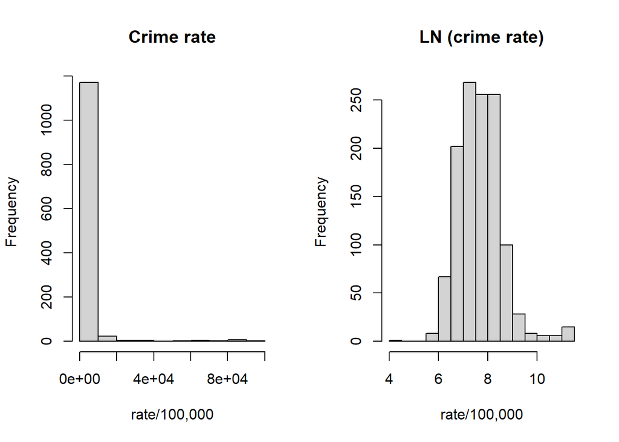

```r
par(mfrow = c(1, 2))
hist(data_complete$crime_rate, main='Crime rate', xlab='rate/100,000')
hist(data_complete$ln_crime_rate,main='LN (crime rate)', xlab='rate/100,000')
```

```r
par(mfrow = c(1, 1))

describe(data_complete$ln_crime_rate)
```

```
##    vars    n mean   sd median trimmed  mad  min   max range skew kurtosis   se
## X1    1 1221 7.68 0.89   7.62    7.62 0.83 4.22 11.45  7.24 0.98     2.64 0.03
```

# Fit the Additive Model 1

Fit the full model with all candidate variables, and check for multicollinearity

```r
model1 <- lm(ln_crime_rate ~
Year+
Sectors+
SHORTEST_DISTANCE_TO_LRT_METERS+
SHORTEST_DISTANCE_TO_POLICE_METERS+
male_percentage+
age_75_plus_percentage+
TotalPermits+
calgary_cma_average_hourly_wage_rate+
property_assessment_median+
canada_unemployment_rate, data_complete)

summary(model1)
```

```
##
## Call:
## lm(formula = ln_crime_rate ~ Year + Sectors + SHORTEST_DISTANCE_TO_LRT_METERS +
##     SHORTEST_DISTANCE_TO_POLICE_METERS + male_percentage + age_75_plus_percentage +
##     TotalPermits + calgary_cma_average_hourly_wage_rate + property_assessment_median +
##     canada_unemployment_rate, data = data_complete)
##
## Residuals:
##      Min       1Q   Median       3Q      Max
## -2.98332 -0.31934 -0.04726  0.31071  2.39567
##
## Coefficients:
##                                        Estimate Std. Error t value Pr(>|t|)
## (Intercept)                           4.534e+02  1.190e+02   3.811 0.000145 ***
## Year                                 -2.258e-01  5.998e-02  -3.764 0.000175 ***
## SectorsEAST                          -1.750e-01  8.965e-02  -1.952 0.051173 .
## SectorsNORTH                         -6.028e-01  9.104e-02  -6.621 5.35e-11 ***
## SectorsNORTHEAST                     -5.582e-01  6.498e-02  -8.591  < 2e-16 ***
## SectorsNORTHWEST                     -6.464e-01  6.992e-02  -9.244  < 2e-16 ***
## SectorsSOUTH                         -8.129e-01  5.122e-02 -15.869  < 2e-16 ***
## SectorsSOUTHEAST                     -3.554e-01  1.024e-01  -3.469 0.000541 ***
## SectorsWEST                          -7.541e-01  5.922e-02 -12.734  < 2e-16 ***
## SHORTEST_DISTANCE_TO_LRT_METERS      -4.232e-05  1.511e-05  -2.801 0.005178 **
## SHORTEST_DISTANCE_TO_POLICE_METERS   -7.036e-05  1.092e-05  -6.443 1.69e-10 ***
## male_percentage                       1.026e-01  4.890e-03  20.989  < 2e-16 ***
## age_75_plus_percentage                7.830e-02  3.927e-03  19.938  < 2e-16 ***
## TotalPermits                          1.221e-03  1.758e-04   6.947 6.10e-12 ***
## calgary_cma_average_hourly_wage_rate  1.761e-01  6.759e-02   2.606 0.009286 **
## property_assessment_median           -1.693e-07  5.432e-08  -3.116 0.001877 **
## canada_unemployment_rate             -6.311e+00  1.671e+00  -3.776 0.000167 ***
## ---
## Signif. codes:  0 '***' 0.001 '**' 0.01 '*' 0.05 '.' 0.1 ' ' 1
##
## Residual standard error: 0.5732 on 1204 degrees of freedom
## Multiple R-squared:  0.5934, Adjusted R-squared:  0.588
## F-statistic: 109.8 on 16 and 1204 DF,  p-value: < 2.2e-16
```

## Check Model 1 for MultiCollinearity

```r
imcdiag(model1, method="VIF")
```

```
##
## Call:
## imcdiag(mod = model1, method = "VIF")
##
##
##  VIF Multicollinearity Diagnostics
##
##                                          VIF detection
## Year                                 38.9933         1
## SectorsEAST                           1.5052         0
## SectorsNORTH                          2.7094         0
## SectorsNORTHEAST                      1.3904         0
## SectorsNORTHWEST                      1.7401         0
## SectorsSOUTH                          1.5008         0
## SectorsSOUTHEAST                      2.1638         0
## SectorsWEST                           1.3881         0
## SHORTEST_DISTANCE_TO_LRT_METERS       4.1931         0
## SHORTEST_DISTANCE_TO_POLICE_METERS    2.3935         0
## male_percentage                       1.7300         0
## age_75_plus_percentage                1.3276         0
## TotalPermits                          1.2984         0
## calgary_cma_average_hourly_wage_rate 37.6036         1
## property_assessment_median            1.2543         0
## canada_unemployment_rate              2.4450         0
##
## Multicollinearity may be due to Year calgary_cma_average_hourly_wage_rate regressors
##
## 1 --> COLLINEARITY is detected by the test
## 0 --> COLLINEARITY is not detected by the test
##
## ===================================
```

# Fit Reduced Model 2

```r
model2 <- lm(ln_crime_rate ~
Year+
Sectors+
SHORTEST_DISTANCE_TO_LRT_METERS+
SHORTEST_DISTANCE_TO_POLICE_METERS+
male_percentage+
age_75_plus_percentage+
TotalPermits+
property_assessment_median+
canada_unemployment_rate, data_complete)

summary(model2)
```

```
##
## Call:
## lm(formula = ln_crime_rate ~ Year + Sectors + SHORTEST_DISTANCE_TO_LRT_METERS +
##     SHORTEST_DISTANCE_TO_POLICE_METERS + male_percentage + age_75_plus_percentage +
##     TotalPermits + property_assessment_median + canada_unemployment_rate,
##     data = data_complete)
##
## Residuals:
##      Min       1Q   Median       3Q      Max
## -2.96709 -0.33151 -0.04654  0.30984  2.42480
##
## Coefficients:
##                                      Estimate Std. Error t value Pr(>|t|)
## (Intercept)                         1.477e+02  1.983e+01   7.449 1.79e-13 ***
## Year                               -7.158e-02  9.810e-03  -7.297 5.32e-13 ***
## SectorsEAST                        -1.735e-01  8.986e-02  -1.931 0.053750 .
## SectorsNORTH                       -6.032e-01  9.126e-02  -6.610 5.76e-11 ***
## SectorsNORTHEAST                   -5.570e-01  6.513e-02  -8.551  < 2e-16 ***
## SectorsNORTHWEST                   -6.473e-01  7.009e-02  -9.235  < 2e-16 ***
## SectorsSOUTH                       -8.129e-01  5.135e-02 -15.831  < 2e-16 ***
## SectorsSOUTHEAST                   -3.555e-01  1.027e-01  -3.462 0.000556 ***
## SectorsWEST                        -7.544e-01  5.936e-02 -12.709  < 2e-16 ***
## SHORTEST_DISTANCE_TO_LRT_METERS    -4.210e-05  1.515e-05  -2.780 0.005528 **
## SHORTEST_DISTANCE_TO_POLICE_METERS -7.023e-05  1.095e-05  -6.415 2.02e-10 ***
## male_percentage                     1.025e-01  4.902e-03  20.918  < 2e-16 ***
## age_75_plus_percentage              7.823e-02  3.937e-03  19.873  < 2e-16 ***
## TotalPermits                        1.208e-03  1.761e-04   6.860 1.10e-11 ***
## property_assessment_median         -1.673e-07  5.444e-08  -3.073 0.002169 **
## canada_unemployment_rate           -3.012e+00  1.093e+00  -2.755 0.005961 **
## ---
## Signif. codes:  0 '***' 0.001 '**' 0.01 '*' 0.05 '.' 0.1 ' ' 1
##
## Residual standard error: 0.5746 on 1205 degrees of freedom
## Multiple R-squared:  0.5911, Adjusted R-squared:  0.586
## F-statistic: 116.1 on 15 and 1205 DF,  p-value: < 2.2e-16
```

## Check Model 2 for MultiCollinearity

```r
imcdiag(mod = model2, method = "VIF")
```

```
##
## Call:
## imcdiag(mod = model2, method = "VIF")
##
##
##  VIF Multicollinearity Diagnostics
##
##                                       VIF detection
## Year                               1.0380         0
## SectorsEAST                        1.5052         0
## SectorsNORTH                       2.7094         0
## SectorsNORTHEAST                   1.3903         0
## SectorsNORTHWEST                   1.7401         0
## SectorsSOUTH                       1.5008         0
## SectorsSOUTHEAST                   2.1638         0
## SectorsWEST                        1.3881         0
## SHORTEST_DISTANCE_TO_LRT_METERS    4.1930         0
## SHORTEST_DISTANCE_TO_POLICE_METERS 2.3934         0
## male_percentage                    1.7299         0
## age_75_plus_percentage             1.3275         0
## TotalPermits                       1.2974         0
## property_assessment_median         1.2541         0
## canada_unemployment_rate           1.0418         0
##
## NOTE:  VIF Method Failed to detect multicollinearity
##
##
## 0 --> COLLINEARITY is not detected by the test
##
## ===================================
```

In model2, all VIF’s < 5.0, suggesting moderate collinearity, but it is not severe enough to warrant corrective measures.

Although we planned to use step-wise for selecting variables, but it is not necessary at this point, as in model2, the individual t-test for all the candidate variables had p<0.05.

# Fit Interaction Model

## Fit Interaction Model 3

So we move onto testing all possible two way interactions:

```r
model3 <- lm(ln_crime_rate ~
(Year+
Sectors+
SHORTEST_DISTANCE_TO_LRT_METERS+
SHORTEST_DISTANCE_TO_POLICE_METERS+
male_percentage+
age_75_plus_percentage+
TotalPermits+
property_assessment_median+
canada_unemployment_rate)^2, data_complete)

summary(model3)
```

```
##
## Call:
## lm(formula = ln_crime_rate ~ (Year + Sectors + SHORTEST_DISTANCE_TO_LRT_METERS +
##     SHORTEST_DISTANCE_TO_POLICE_METERS + male_percentage + age_75_plus_percentage +
##     TotalPermits + property_assessment_median + canada_unemployment_rate)^2,
##     data = data_complete)
##
## Residuals:
##      Min       1Q   Median       3Q      Max
## -3.13959 -0.24404 -0.00168  0.23170  1.92662
##
## Coefficients:
##                                                                      Estimate
## (Intercept)                                                         4.274e+02
## Year                                                               -2.095e-01
## SectorsEAST                                                        -9.700e+01
## SectorsNORTH                                                       -5.068e+01
## SectorsNORTHEAST                                                   -8.103e+01
## SectorsNORTHWEST                                                   -4.713e+01
## SectorsSOUTH                                                        1.050e+01
## SectorsSOUTHEAST                                                    6.606e+01
## SectorsWEST                                                         7.043e+00
## SHORTEST_DISTANCE_TO_LRT_METERS                                    -1.155e-02
## SHORTEST_DISTANCE_TO_POLICE_METERS                                  1.251e-02
## male_percentage                                                    -1.109e+01
## age_75_plus_percentage                                             -6.678e+00
## TotalPermits                                                       -1.044e+00
## property_assessment_median                                          1.128e-04
## canada_unemployment_rate                                            5.947e+03
## Year:SectorsEAST                                                    4.741e-02
## Year:SectorsNORTH                                                   3.311e-02
## Year:SectorsNORTHEAST                                               4.408e-02
## Year:SectorsNORTHWEST                                               2.045e-02
## Year:SectorsSOUTH                                                  -7.176e-03
## Year:SectorsSOUTHEAST                                              -3.504e-02
## Year:SectorsWEST                                                   -4.052e-03
## Year:SHORTEST_DISTANCE_TO_LRT_METERS                                4.637e-06
## Year:SHORTEST_DISTANCE_TO_POLICE_METERS                            -6.156e-06
## Year:male_percentage                                                5.533e-03
## Year:age_75_plus_percentage                                         3.418e-03
```

[output cut: 367 more lines]

```
## male_percentage:TotalPermits                                       0.151269
## male_percentage:property_assessment_median                         0.000740 ***
## male_percentage:canada_unemployment_rate                           0.467393
## age_75_plus_percentage:TotalPermits                                0.099332 .
## age_75_plus_percentage:property_assessment_median                  0.233531
## age_75_plus_percentage:canada_unemployment_rate                    0.333151
## TotalPermits:property_assessment_median                            0.184390
## TotalPermits:canada_unemployment_rate                              0.938067
## property_assessment_median:canada_unemployment_rate                0.039430 *
## ---
## Signif. codes:  0 '***' 0.001 '**' 0.01 '*' 0.05 '.' 0.1 ' ' 1
##
## Residual standard error: 0.4386 on 1121 degrees of freedom
## Multiple R-squared:  0.7784, Adjusted R-squared:  0.7588
## F-statistic: 39.77 on 99 and 1121 DF,  p-value: < 2.2e-16
```

Evaluate interaction terms significance using individual t-test.

$H_0$: 𝛽$_i$ = 0 $H_a$: 𝛽$_i \neq$ 0 $\alpha=0.05$

The following interaction terms had p<0.05:

Year:male_percentage_num 2.413 0.015997 *  
Year:TotalPermits 5.620 2.41e-08 *Year:canada_unemployment_rate_num -2.091 0.036737*  
**SectorsEAST:SHORTEST_DISTANCE_TO_LRT_METERS -3.098 0.001995** SectorsNORTH:SHORTEST_DISTANCE_TO_LRT_METERS 1.966 0.049571 *  
SectorsSOUTH:SHORTEST_DISTANCE_TO_LRT_METERS -2.853 0.004406 ** SectorsSOUTHEAST:SHORTEST_DISTANCE_TO_LRT_METERS 2.134 0.033069 *  
SectorsWEST:SHORTEST_DISTANCE_TO_LRT_METERS 4.588 4.99e-06 **SectorsEAST:SHORTEST_DISTANCE_TO_POLICE_METERS 2.662 0.007884** SectorsSOUTH:SHORTEST_DISTANCE_TO_POLICE_METERS 1.964 0.049782  
SectorsWEST:SHORTEST_DISTANCE_TO_POLICE_METERS -3.185 0.001489 ** SectorsNORTH:male_percentage_num -3.817 0.000143 **SectorsNORTHEAST:male_percentage_num -2.897 0.003840** SectorsSOUTH:male_percentage_num 1.982 0.047713  
SectorsNORTHEAST:age_75_plus_percentage_num 2.505 0.012370 *  
SectorsSOUTHEAST:age_75_plus_percentage_num 4.931 9.42e-07 **SectorsNORTH:TotalPermits -3.043 0.002396** SectorsNORTHEAST:TotalPermits -4.637 3.95e-06 **SectorsNORTHWEST:TotalPermits 3.595 0.000339** *SectorsSOUTHEAST:TotalPermits -3.979 7.37e-05* **SectorsNORTHWEST:median 4.215 2.70e-05** *SectorsSOUTH:median 5.711 1.44e-08* **SectorsSOUTHEAST:median 3.244 0.001214** SHORTEST_DISTANCE_TO_LRT_METERS:SHORTEST_DISTANCE_TO_POLICE_METERS 2.026 0.043004 *  
SHORTEST_DISTANCE_TO_LRT_METERS:male_percentage_num 3.571 0.000371 **SHORTEST_DISTANCE_TO_LRT_METERS:age_75_plus_percentage_num 3.063 0.002245** SHORTEST_DISTANCE_TO_LRT_METERS:TotalPermits 2.553 0.010821  
SHORTEST_DISTANCE_TO_POLICE_METERS:median -2.096 0.036288 *  
male_percentage_num:age_75_plus_percentage_num -3.287 0.001045 ** male_percentage_num:median -3.384 0.000740 ** *median:canada_unemployment_rate_num 2.062 0.039430*

We will include these interaction terms in the model:

Yearmale_percentage_num+  
YearTotalPermits+  
Yearcanada_unemployment_rate_num+  
SectorsSHORTEST_DISTANCE_TO_LRT_METERS+  
SectorsSHORTEST_DISTANCE_TO_POLICE_METERS+  
Sectorsmale_percentage_num+  
Sectorsage_75_plus_percentage_num+  
SectorsTotalPermits+  
Sectorsmedian+  
SHORTEST_DISTANCE_TO_LRT_METERSSHORTEST_DISTANCE_TO_POLICE_METERS+  
SHORTEST_DISTANCE_TO_LRT_METERSmale_percentage_num+  
SHORTEST_DISTANCE_TO_LRT_METERSage_75_plus_percentage_num+  
SHORTEST_DISTANCE_TO_LRT_METERSTotalPermits+  
SHORTEST_DISTANCE_TO_POLICE_METERSmedian+  
male_percentage_numage_75_plus_percentage_num+  
male_percentage_nummedian+  
median*canada_unemployment_rate_num

## Fit Interaction Model 4

Then we run the model with the interaction terms:

```r
model4 <- lm(ln_crime_rate ~
Year+
Sectors+
SHORTEST_DISTANCE_TO_LRT_METERS+
SHORTEST_DISTANCE_TO_POLICE_METERS+
male_percentage+
age_75_plus_percentage+
TotalPermits+
property_assessment_median+
canada_unemployment_rate +
Year*male_percentage+
Year*TotalPermits+
Year*canada_unemployment_rate +
Sectors*SHORTEST_DISTANCE_TO_LRT_METERS+
Sectors*SHORTEST_DISTANCE_TO_POLICE_METERS+
Sectors*male_percentage +
Sectors*age_75_plus_percentage+
Sectors*TotalPermits+
Sectors*property_assessment_median+
SHORTEST_DISTANCE_TO_LRT_METERS*SHORTEST_DISTANCE_TO_POLICE_METERS+
SHORTEST_DISTANCE_TO_LRT_METERS*male_percentage+
SHORTEST_DISTANCE_TO_LRT_METERS*age_75_plus_percentage+
SHORTEST_DISTANCE_TO_LRT_METERS*TotalPermits+
SHORTEST_DISTANCE_TO_POLICE_METERS*property_assessment_median+
male_percentage*age_75_plus_percentage+
male_percentage*property_assessment_median+
property_assessment_median*canada_unemployment_rate
  , data_complete)


summary(model4)
```

```
##
## Call:
## lm(formula = ln_crime_rate ~ Year + Sectors + SHORTEST_DISTANCE_TO_LRT_METERS +
##     SHORTEST_DISTANCE_TO_POLICE_METERS + male_percentage + age_75_plus_percentage +
##     TotalPermits + property_assessment_median + canada_unemployment_rate +
##     Year * male_percentage + Year * TotalPermits + Year * canada_unemployment_rate +
##     Sectors * SHORTEST_DISTANCE_TO_LRT_METERS + Sectors * SHORTEST_DISTANCE_TO_POLICE_METERS +
##     Sectors * male_percentage + Sectors * age_75_plus_percentage +
##     Sectors * TotalPermits + Sectors * property_assessment_median +
##     SHORTEST_DISTANCE_TO_LRT_METERS * SHORTEST_DISTANCE_TO_POLICE_METERS +
##     SHORTEST_DISTANCE_TO_LRT_METERS * male_percentage + SHORTEST_DISTANCE_TO_LRT_METERS *
##     age_75_plus_percentage + SHORTEST_DISTANCE_TO_LRT_METERS *
##     TotalPermits + SHORTEST_DISTANCE_TO_POLICE_METERS * property_assessment_median +
##     male_percentage * age_75_plus_percentage + male_percentage *
##     property_assessment_median + property_assessment_median *
##     canada_unemployment_rate, data = data_complete)
##
## Residuals:
##     Min      1Q  Median      3Q     Max
## -3.0245 -0.2451  0.0041  0.2397  1.8977
##
## Coefficients:
##                                                                      Estimate
## (Intercept)                                                         3.517e+02
## Year                                                               -1.719e-01
## SectorsEAST                                                        -9.599e-01
## SectorsNORTH                                                        1.705e+01
## SectorsNORTHEAST                                                    6.112e+00
## SectorsNORTHWEST                                                   -6.504e+00
## SectorsSOUTH                                                       -4.543e+00
## SectorsSOUTHEAST                                                   -3.776e+00
## SectorsWEST                                                        -1.632e+00
## SHORTEST_DISTANCE_TO_LRT_METERS                                    -2.323e-03
## SHORTEST_DISTANCE_TO_POLICE_METERS                                  1.921e-07
## male_percentage                                                    -8.700e+00
## age_75_plus_percentage                                              2.549e-01
## TotalPermits                                                       -9.227e-01
## property_assessment_median                                          3.867e-06
## canada_unemployment_rate                                            5.409e+03
## Year:male_percentage                                                4.351e-03
```

[output cut: 253 more lines]

```
## SectorsWEST:property_assessment_median                             0.259964
## SHORTEST_DISTANCE_TO_LRT_METERS:SHORTEST_DISTANCE_TO_POLICE_METERS 0.045698 *
## SHORTEST_DISTANCE_TO_LRT_METERS:male_percentage                    1.76e-06 ***
## SHORTEST_DISTANCE_TO_LRT_METERS:age_75_plus_percentage             0.000139 ***
## SHORTEST_DISTANCE_TO_LRT_METERS:TotalPermits                       0.003805 **
## SHORTEST_DISTANCE_TO_POLICE_METERS:property_assessment_median      0.003188 **
## male_percentage:age_75_plus_percentage                             2.46e-06 ***
## male_percentage:property_assessment_median                         2.14e-05 ***
## property_assessment_median:canada_unemployment_rate                0.123148
## ---
## Signif. codes:  0 '***' 0.001 '**' 0.01 '*' 0.05 '.' 0.1 ' ' 1
##
## Residual standard error: 0.4401 on 1152 degrees of freedom
## Multiple R-squared:  0.7707, Adjusted R-squared:  0.7571
## F-statistic: 56.93 on 68 and 1152 DF,  p-value: < 2.2e-16
```

### Fit Interaction Model 4b

```r
model4b <- lm(ln_crime_rate ~
Year+
Sectors+
SHORTEST_DISTANCE_TO_LRT_METERS+
SHORTEST_DISTANCE_TO_POLICE_METERS+
male_percentage+
age_75_plus_percentage+
TotalPermits+
property_assessment_median+
canada_unemployment_rate+
Year*male_percentage+
Year*TotalPermits+
Sectors*SHORTEST_DISTANCE_TO_LRT_METERS+
Sectors*SHORTEST_DISTANCE_TO_POLICE_METERS+
Sectors*male_percentage+
Sectors*age_75_plus_percentage+
Sectors*TotalPermits+
Sectors*property_assessment_median+
SHORTEST_DISTANCE_TO_LRT_METERS*SHORTEST_DISTANCE_TO_POLICE_METERS+
SHORTEST_DISTANCE_TO_LRT_METERS*male_percentage+
SHORTEST_DISTANCE_TO_LRT_METERS*age_75_plus_percentage+
SHORTEST_DISTANCE_TO_LRT_METERS*TotalPermits+
SHORTEST_DISTANCE_TO_POLICE_METERS*property_assessment_median+
male_percentage*age_75_plus_percentage+
male_percentage*property_assessment_median, data_complete)


summary(model4b)
```

```
##
## Call:
## lm(formula = ln_crime_rate ~ Year + Sectors + SHORTEST_DISTANCE_TO_LRT_METERS +
##     SHORTEST_DISTANCE_TO_POLICE_METERS + male_percentage + age_75_plus_percentage +
##     TotalPermits + property_assessment_median + canada_unemployment_rate +
##     Year * male_percentage + Year * TotalPermits + Sectors *
##     SHORTEST_DISTANCE_TO_LRT_METERS + Sectors * SHORTEST_DISTANCE_TO_POLICE_METERS +
##     Sectors * male_percentage + Sectors * age_75_plus_percentage +
##     Sectors * TotalPermits + Sectors * property_assessment_median +
##     SHORTEST_DISTANCE_TO_LRT_METERS * SHORTEST_DISTANCE_TO_POLICE_METERS +
##     SHORTEST_DISTANCE_TO_LRT_METERS * male_percentage + SHORTEST_DISTANCE_TO_LRT_METERS *
##     age_75_plus_percentage + SHORTEST_DISTANCE_TO_LRT_METERS *
##     TotalPermits + SHORTEST_DISTANCE_TO_POLICE_METERS * property_assessment_median +
##     male_percentage * age_75_plus_percentage + male_percentage *
##     property_assessment_median, data = data_complete)
##
## Residuals:
##      Min       1Q   Median       3Q      Max
## -3.01258 -0.25065 -0.00041  0.23757  1.88668
##
## Coefficients:
##                                                                      Estimate
## (Intercept)                                                         6.443e+02
## Year                                                               -3.168e-01
## SectorsEAST                                                        -9.682e-01
## SectorsNORTH                                                        1.716e+01
## SectorsNORTHEAST                                                    6.061e+00
## SectorsNORTHWEST                                                   -6.752e+00
## SectorsSOUTH                                                       -4.527e+00
## SectorsSOUTHEAST                                                   -3.759e+00
## SectorsWEST                                                        -1.610e+00
## SHORTEST_DISTANCE_TO_LRT_METERS                                    -2.307e-03
## SHORTEST_DISTANCE_TO_POLICE_METERS                                 -2.213e-06
## male_percentage                                                    -8.410e+00
## age_75_plus_percentage                                              2.573e-01
## TotalPermits                                                       -9.189e-01
## property_assessment_median                                          4.070e-06
## canada_unemployment_rate                                           -2.894e+00
## Year:male_percentage                                                4.208e-03
## Year:TotalPermits                                                   4.557e-04
```

[output cut: 244 more lines]

```
## SectorsSOUTHEAST:property_assessment_median                        0.009920 **
## SectorsWEST:property_assessment_median                             0.288909
## SHORTEST_DISTANCE_TO_LRT_METERS:SHORTEST_DISTANCE_TO_POLICE_METERS 0.044928 *
## SHORTEST_DISTANCE_TO_LRT_METERS:male_percentage                    2.18e-06 ***
## SHORTEST_DISTANCE_TO_LRT_METERS:age_75_plus_percentage             0.000163 ***
## SHORTEST_DISTANCE_TO_LRT_METERS:TotalPermits                       0.004006 **
## SHORTEST_DISTANCE_TO_POLICE_METERS:property_assessment_median      0.004412 **
## male_percentage:age_75_plus_percentage                             2.09e-06 ***
## male_percentage:property_assessment_median                         2.52e-05 ***
## ---
## Signif. codes:  0 '***' 0.001 '**' 0.01 '*' 0.05 '.' 0.1 ' ' 1
##
## Residual standard error: 0.4409 on 1154 degrees of freedom
## Multiple R-squared:  0.7695, Adjusted R-squared:  0.7563
## F-statistic: 58.36 on 66 and 1154 DF,  p-value: < 2.2e-16
```

# Fit Higher Order Term Model

Next we move on to testing higher order terms. We use the function pairs() to see how the response looks with respect to each independent variable. We look at all pairwise combinations of continuous variables in scatterplots.

## Plot Pairs

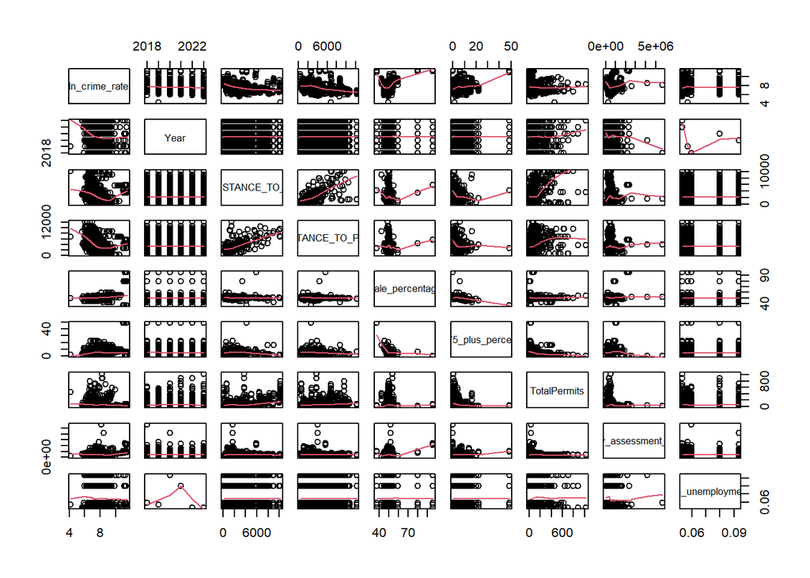

```r
pairs(~ln_crime_rate +
Year+
SHORTEST_DISTANCE_TO_LRT_METERS+
SHORTEST_DISTANCE_TO_POLICE_METERS+
male_percentage+
age_75_plus_percentage+
TotalPermits+
property_assessment_median+
canada_unemployment_rate, data_complete, panel=panel.smooth)
```

It looked like there might be some concavity in the

ln_crime_rate vs. Year, ln_crime_rate vs.SHORTEST_DISTANCE_TO_LRT_METERS ln_crime_rate vs.SHORTEST_DISTANCE_TO_POLICE_METERS

### Fit Quadratic Model 5 - Year Squared

We fitted a quadratic model and the linear model and see which one might be the best fit.

```r
model5 <- lm(ln_crime_rate ~
Year+
I(Year^2)+
Sectors+
SHORTEST_DISTANCE_TO_LRT_METERS+
SHORTEST_DISTANCE_TO_POLICE_METERS+
male_percentage+
age_75_plus_percentage+
TotalPermits+
property_assessment_median+
canada_unemployment_rate, data_complete)

summary(model5)
```

```
##
## Call:
## lm(formula = ln_crime_rate ~ Year + I(Year^2) + Sectors + SHORTEST_DISTANCE_TO_LRT_METERS +
##     SHORTEST_DISTANCE_TO_POLICE_METERS + male_percentage + age_75_plus_percentage +
##     TotalPermits + property_assessment_median + canada_unemployment_rate,
##     data = data_complete)
##
## Residuals:
##      Min       1Q   Median       3Q      Max
## -3.00570 -0.32308 -0.03429  0.31082  2.38563
##
## Coefficients:
##                                      Estimate Std. Error t value Pr(>|t|)
## (Intercept)                        -8.323e+04  3.838e+04  -2.169 0.030291 *
## Year                                8.246e+01  3.799e+01   2.171 0.030142 *
## I(Year^2)                          -2.043e-02  9.401e-03  -2.173 0.029999 *
## SectorsEAST                        -1.713e-01  8.973e-02  -1.910 0.056431 .
## SectorsNORTH                       -6.024e-01  9.112e-02  -6.611 5.70e-11 ***
## SectorsNORTHEAST                   -5.555e-01  6.503e-02  -8.541  < 2e-16 ***
## SectorsNORTHWEST                   -6.484e-01  6.998e-02  -9.265  < 2e-16 ***
## SectorsSOUTH                       -8.126e-01  5.127e-02 -15.851  < 2e-16 ***
## SectorsSOUTHEAST                   -3.542e-01  1.025e-01  -3.455 0.000569 ***
## SectorsWEST                        -7.545e-01  5.927e-02 -12.731  < 2e-16 ***
## SHORTEST_DISTANCE_TO_LRT_METERS    -4.227e-05  1.512e-05  -2.795 0.005267 **
## SHORTEST_DISTANCE_TO_POLICE_METERS -7.008e-05  1.093e-05  -6.411 2.07e-10 ***
## male_percentage                     1.023e-01  4.896e-03  20.898  < 2e-16 ***
## age_75_plus_percentage              7.815e-02  3.931e-03  19.881  < 2e-16 ***
## TotalPermits                        1.205e-03  1.759e-04   6.852 1.16e-11 ***
## property_assessment_median         -1.609e-07  5.444e-08  -2.957 0.003171 **
## canada_unemployment_rate           -5.413e+00  1.553e+00  -3.485 0.000510 ***
## ---
## Signif. codes:  0 '***' 0.001 '**' 0.01 '*' 0.05 '.' 0.1 ' ' 1
##
## Residual standard error: 0.5737 on 1204 degrees of freedom
## Multiple R-squared:  0.5927, Adjusted R-squared:  0.5873
## F-statistic: 109.5 on 16 and 1204 DF,  p-value: < 2.2e-16
```

### Fit Cubic Model 5b - Year Squared and Year Cubed

```r
model5b <- lm(ln_crime_rate ~
Year+
I(Year^2)+
I(Year^3)+
Sectors+
SHORTEST_DISTANCE_TO_LRT_METERS+
SHORTEST_DISTANCE_TO_POLICE_METERS+
male_percentage+
age_75_plus_percentage+
TotalPermits+
property_assessment_median+
canada_unemployment_rate, data_complete)

summary(model5b)
```

```
##
## Call:
## lm(formula = ln_crime_rate ~ Year + I(Year^2) + I(Year^3) + Sectors +
##     SHORTEST_DISTANCE_TO_LRT_METERS + SHORTEST_DISTANCE_TO_POLICE_METERS +
##     male_percentage + age_75_plus_percentage + TotalPermits +
##     property_assessment_median + canada_unemployment_rate, data = data_complete)
##
## Residuals:
##      Min       1Q   Median       3Q      Max
## -3.00570 -0.32308 -0.03429  0.31082  2.38563
##
## Coefficients: (1 not defined because of singularities)
##                                      Estimate Std. Error t value Pr(>|t|)
## (Intercept)                        -8.323e+04  3.838e+04  -2.169 0.030291 *
## Year                                8.246e+01  3.799e+01   2.171 0.030142 *
## I(Year^2)                          -2.043e-02  9.401e-03  -2.173 0.029999 *
## I(Year^3)                                  NA         NA      NA       NA
## SectorsEAST                        -1.713e-01  8.973e-02  -1.910 0.056431 .
## SectorsNORTH                       -6.024e-01  9.112e-02  -6.611 5.70e-11 ***
## SectorsNORTHEAST                   -5.555e-01  6.503e-02  -8.541  < 2e-16 ***
## SectorsNORTHWEST                   -6.484e-01  6.998e-02  -9.265  < 2e-16 ***
## SectorsSOUTH                       -8.126e-01  5.127e-02 -15.851  < 2e-16 ***
## SectorsSOUTHEAST                   -3.542e-01  1.025e-01  -3.455 0.000569 ***
## SectorsWEST                        -7.545e-01  5.927e-02 -12.731  < 2e-16 ***
## SHORTEST_DISTANCE_TO_LRT_METERS    -4.227e-05  1.512e-05  -2.795 0.005267 **
## SHORTEST_DISTANCE_TO_POLICE_METERS -7.008e-05  1.093e-05  -6.411 2.07e-10 ***
## male_percentage                     1.023e-01  4.896e-03  20.898  < 2e-16 ***
## age_75_plus_percentage              7.815e-02  3.931e-03  19.881  < 2e-16 ***
## TotalPermits                        1.205e-03  1.759e-04   6.852 1.16e-11 ***
## property_assessment_median         -1.609e-07  5.444e-08  -2.957 0.003171 **
## canada_unemployment_rate           -5.413e+00  1.553e+00  -3.485 0.000510 ***
## ---
## Signif. codes:  0 '***' 0.001 '**' 0.01 '*' 0.05 '.' 0.1 ' ' 1
##
## Residual standard error: 0.5737 on 1204 degrees of freedom
## Multiple R-squared:  0.5927, Adjusted R-squared:  0.5873
## F-statistic: 109.5 on 16 and 1204 DF,  p-value: < 2.2e-16
```

### Fit Quadratic Model 5c - Year Squared and Shortest Distance to LRT Squared

```r
model5c <- lm(ln_crime_rate ~
Year+
I(Year^2)+
Sectors+
SHORTEST_DISTANCE_TO_LRT_METERS+
I(SHORTEST_DISTANCE_TO_LRT_METERS^2)+
SHORTEST_DISTANCE_TO_POLICE_METERS+
male_percentage+
age_75_plus_percentage+
TotalPermits+
property_assessment_median+
canada_unemployment_rate, data_complete)

summary(model5c)
```

```
##
## Call:
## lm(formula = ln_crime_rate ~ Year + I(Year^2) + Sectors + SHORTEST_DISTANCE_TO_LRT_METERS +
##     I(SHORTEST_DISTANCE_TO_LRT_METERS^2) + SHORTEST_DISTANCE_TO_POLICE_METERS +
##     male_percentage + age_75_plus_percentage + TotalPermits +
##     property_assessment_median + canada_unemployment_rate, data = data_complete)
##
## Residuals:
##     Min      1Q  Median      3Q     Max
## -3.2981 -0.3324 -0.0310  0.3099  2.4817
##
## Coefficients:
##                                        Estimate Std. Error t value Pr(>|t|)
## (Intercept)                          -8.322e+04  3.809e+04  -2.185 0.029083 *
## Year                                  8.246e+01  3.770e+01   2.187 0.028938 *
## I(Year^2)                            -2.042e-02  9.331e-03  -2.189 0.028800 *
## SectorsEAST                          -1.328e-01  8.949e-02  -1.484 0.138062
## SectorsNORTH                         -6.505e-01  9.110e-02  -7.140 1.61e-12 ***
## SectorsNORTHEAST                     -4.910e-01  6.620e-02  -7.417 2.26e-13 ***
## SectorsNORTHWEST                     -6.195e-01  6.977e-02  -8.879  < 2e-16 ***
## SectorsSOUTH                         -7.709e-01  5.177e-02 -14.893  < 2e-16 ***
## SectorsSOUTHEAST                     -4.371e-01  1.035e-01  -4.224 2.58e-05 ***
## SectorsWEST                          -7.149e-01  5.951e-02 -12.012  < 2e-16 ***
## SHORTEST_DISTANCE_TO_LRT_METERS      -1.414e-04  2.713e-05  -5.213 2.19e-07 ***
## I(SHORTEST_DISTANCE_TO_LRT_METERS^2)  1.337e-08  3.048e-09   4.387 1.25e-05 ***
## SHORTEST_DISTANCE_TO_POLICE_METERS   -6.988e-05  1.085e-05  -6.441 1.71e-10 ***
## male_percentage                       1.026e-01  4.859e-03  21.121  < 2e-16 ***
## age_75_plus_percentage                7.848e-02  3.902e-03  20.112  < 2e-16 ***
## TotalPermits                          8.896e-04  1.888e-04   4.712 2.74e-06 ***
## property_assessment_median           -1.547e-07  5.405e-08  -2.862 0.004283 **
## canada_unemployment_rate             -5.344e+00  1.542e+00  -3.466 0.000546 ***
## ---
## Signif. codes:  0 '***' 0.001 '**' 0.01 '*' 0.05 '.' 0.1 ' ' 1
##
## Residual standard error: 0.5694 on 1203 degrees of freedom
## Multiple R-squared:  0.5991, Adjusted R-squared:  0.5935
## F-statistic: 105.8 on 17 and 1203 DF,  p-value: < 2.2e-16
```

### Fit Cubic Model 5d - Shorest Distance to LRT Squared and Cubed

```r
model5d <- lm(ln_crime_rate ~
Year+
I(Year^2)+
Sectors+
SHORTEST_DISTANCE_TO_LRT_METERS+
I(SHORTEST_DISTANCE_TO_LRT_METERS^2)+
I(SHORTEST_DISTANCE_TO_LRT_METERS^3)+
SHORTEST_DISTANCE_TO_POLICE_METERS+
male_percentage+
age_75_plus_percentage+
TotalPermits+
property_assessment_median+
canada_unemployment_rate, data_complete)

summary(model5d)
```

```
##
## Call:
## lm(formula = ln_crime_rate ~ Year + I(Year^2) + Sectors + SHORTEST_DISTANCE_TO_LRT_METERS +
##     I(SHORTEST_DISTANCE_TO_LRT_METERS^2) + I(SHORTEST_DISTANCE_TO_LRT_METERS^3) +
##     SHORTEST_DISTANCE_TO_POLICE_METERS + male_percentage + age_75_plus_percentage +
##     TotalPermits + property_assessment_median + canada_unemployment_rate,
##     data = data_complete)
##
## Residuals:
##      Min       1Q   Median       3Q      Max
## -3.06564 -0.33384 -0.03014  0.31362  2.43668
##
## Coefficients:
##                                        Estimate Std. Error t value Pr(>|t|)
## (Intercept)                          -8.422e+04  3.792e+04  -2.221 0.026533 *
## Year                                  8.345e+01  3.754e+01   2.223 0.026399 *
## I(Year^2)                            -2.067e-02  9.290e-03  -2.225 0.026271 *
## SectorsEAST                          -1.020e-01  8.954e-02  -1.139 0.254873
## SectorsNORTH                         -7.707e-01  9.725e-02  -7.924 5.19e-15 ***
## SectorsNORTHEAST                     -4.755e-01  6.606e-02  -7.199 1.07e-12 ***
## SectorsNORTHWEST                     -5.795e-01  7.044e-02  -8.227 4.93e-16 ***
## SectorsSOUTH                         -7.510e-01  5.186e-02 -14.481  < 2e-16 ***
## SectorsSOUTHEAST                     -5.115e-01  1.053e-01  -4.857 1.35e-06 ***
## SectorsWEST                          -7.067e-01  5.930e-02 -11.918  < 2e-16 ***
## SHORTEST_DISTANCE_TO_LRT_METERS      -3.264e-04  6.039e-05  -5.404 7.84e-08 ***
## I(SHORTEST_DISTANCE_TO_LRT_METERS^2)  6.878e-08  1.647e-08   4.177 3.17e-05 ***
## I(SHORTEST_DISTANCE_TO_LRT_METERS^3) -3.871e-12  1.131e-12  -3.424 0.000638 ***
## SHORTEST_DISTANCE_TO_POLICE_METERS   -7.576e-05  1.094e-05  -6.928 6.96e-12 ***
## male_percentage                       9.982e-02  4.907e-03  20.342  < 2e-16 ***
## age_75_plus_percentage                7.805e-02  3.887e-03  20.080  < 2e-16 ***
## TotalPermits                          9.087e-04  1.880e-04   4.832 1.52e-06 ***
## property_assessment_median           -1.383e-07  5.402e-08  -2.560 0.010589 *
## canada_unemployment_rate             -5.339e+00  1.535e+00  -3.479 0.000522 ***
## ---
## Signif. codes:  0 '***' 0.001 '**' 0.01 '*' 0.05 '.' 0.1 ' ' 1
##
## Residual standard error: 0.5669 on 1202 degrees of freedom
## Multiple R-squared:  0.603,  Adjusted R-squared:  0.5971
## F-statistic: 101.4 on 18 and 1202 DF,  p-value: < 2.2e-16
```

### Fit Quartic Model 5e - Shortest Distance to LRT Squared to Power of 4

I(SHORTEST_DISTANCE_TO_LRT_METERS^4) not significant

```r
model5e <- lm(ln_crime_rate ~
Year+
I(Year^2)+
Sectors+
SHORTEST_DISTANCE_TO_LRT_METERS+
I(SHORTEST_DISTANCE_TO_LRT_METERS^2)+
I(SHORTEST_DISTANCE_TO_LRT_METERS^3)+
I(SHORTEST_DISTANCE_TO_LRT_METERS^4)+
SHORTEST_DISTANCE_TO_POLICE_METERS+
male_percentage+
age_75_plus_percentage+
TotalPermits+
property_assessment_median+
canada_unemployment_rate, data_complete)

summary(model5e)
```

```
##
## Call:
## lm(formula = ln_crime_rate ~ Year + I(Year^2) + Sectors + SHORTEST_DISTANCE_TO_LRT_METERS +
##     I(SHORTEST_DISTANCE_TO_LRT_METERS^2) + I(SHORTEST_DISTANCE_TO_LRT_METERS^3) +
##     I(SHORTEST_DISTANCE_TO_LRT_METERS^4) + SHORTEST_DISTANCE_TO_POLICE_METERS +
##     male_percentage + age_75_plus_percentage + TotalPermits +
##     property_assessment_median + canada_unemployment_rate, data = data_complete)
##
## Residuals:
##      Min       1Q   Median       3Q      Max
## -3.09551 -0.33115 -0.03302  0.31098  2.42945
##
## Coefficients:
##                                        Estimate Std. Error t value Pr(>|t|)
## (Intercept)                          -8.438e+04  3.793e+04  -2.225  0.02630 *
## Year                                  8.360e+01  3.755e+01   2.227  0.02616 *
## I(Year^2)                            -2.071e-02  9.292e-03  -2.228  0.02604 *
## SectorsEAST                          -9.918e-02  8.969e-02  -1.106  0.26902
## SectorsNORTH                         -7.652e-01  9.771e-02  -7.832 1.05e-14 ***
## SectorsNORTHEAST                     -4.721e-01  6.633e-02  -7.117 1.90e-12 ***
## SectorsNORTHWEST                     -5.750e-01  7.085e-02  -8.117 1.18e-15 ***
## SectorsSOUTH                         -7.486e-01  5.204e-02 -14.384  < 2e-16 ***
## SectorsSOUTHEAST                     -5.065e-01  1.057e-01  -4.794 1.84e-06 ***
## SectorsWEST                          -7.068e-01  5.932e-02 -11.916  < 2e-16 ***
## SHORTEST_DISTANCE_TO_LRT_METERS      -3.886e-04  1.204e-04  -3.227  0.00128 **
## I(SHORTEST_DISTANCE_TO_LRT_METERS^2)  9.793e-08  5.149e-08   1.902  0.05743 .
## I(SHORTEST_DISTANCE_TO_LRT_METERS^3) -8.590e-12  7.981e-12  -1.076  0.28200
## I(SHORTEST_DISTANCE_TO_LRT_METERS^4)  2.416e-16  4.045e-16   0.597  0.55038
## SHORTEST_DISTANCE_TO_POLICE_METERS   -7.596e-05  1.094e-05  -6.940 6.38e-12 ***
## male_percentage                       9.938e-02  4.965e-03  20.018  < 2e-16 ***
## age_75_plus_percentage                7.790e-02  3.896e-03  19.992  < 2e-16 ***
## TotalPermits                          8.886e-04  1.911e-04   4.651 3.67e-06 ***
## property_assessment_median           -1.332e-07  5.471e-08  -2.434  0.01508 *
## canada_unemployment_rate             -5.335e+00  1.535e+00  -3.475  0.00053 ***
## ---
## Signif. codes:  0 '***' 0.001 '**' 0.01 '*' 0.05 '.' 0.1 ' ' 1
##
## Residual standard error: 0.567 on 1201 degrees of freedom
## Multiple R-squared:  0.6031, Adjusted R-squared:  0.5969
## F-statistic: 96.06 on 19 and 1201 DF,  p-value: < 2.2e-16
```

### Fit Cubic Model 6 - Shortest Distance to LRT Squared and Cubed + Interaction Terms

Then we fit a cubic model plus the interaction terms.

```r
model6 <- lm(ln_crime_rate ~
Year+
I(Year^2)+
Sectors+
SHORTEST_DISTANCE_TO_LRT_METERS+
I(SHORTEST_DISTANCE_TO_LRT_METERS^2)+
I(SHORTEST_DISTANCE_TO_LRT_METERS^3)+
SHORTEST_DISTANCE_TO_POLICE_METERS+
male_percentage+
age_75_plus_percentage+
TotalPermits+
property_assessment_median+
canada_unemployment_rate+
Year*male_percentage+
Year*TotalPermits+
Sectors*SHORTEST_DISTANCE_TO_LRT_METERS+
Sectors*SHORTEST_DISTANCE_TO_POLICE_METERS+
Sectors*male_percentage+
Sectors*age_75_plus_percentage+
Sectors*TotalPermits+
Sectors*property_assessment_median+
SHORTEST_DISTANCE_TO_LRT_METERS*SHORTEST_DISTANCE_TO_POLICE_METERS+
SHORTEST_DISTANCE_TO_LRT_METERS*male_percentage+
SHORTEST_DISTANCE_TO_LRT_METERS*age_75_plus_percentage+
SHORTEST_DISTANCE_TO_LRT_METERS*TotalPermits+
SHORTEST_DISTANCE_TO_POLICE_METERS*property_assessment_median+
male_percentage*age_75_plus_percentage+
male_percentage*property_assessment_median, data_complete)

summary(model6)
```

```
##
## Call:
## lm(formula = ln_crime_rate ~ Year + I(Year^2) + Sectors + SHORTEST_DISTANCE_TO_LRT_METERS +
##     I(SHORTEST_DISTANCE_TO_LRT_METERS^2) + I(SHORTEST_DISTANCE_TO_LRT_METERS^3) +
##     SHORTEST_DISTANCE_TO_POLICE_METERS + male_percentage + age_75_plus_percentage +
##     TotalPermits + property_assessment_median + canada_unemployment_rate +
##     Year * male_percentage + Year * TotalPermits + Sectors *
##     SHORTEST_DISTANCE_TO_LRT_METERS + Sectors * SHORTEST_DISTANCE_TO_POLICE_METERS +
##     Sectors * male_percentage + Sectors * age_75_plus_percentage +
##     Sectors * TotalPermits + Sectors * property_assessment_median +
##     SHORTEST_DISTANCE_TO_LRT_METERS * SHORTEST_DISTANCE_TO_POLICE_METERS +
##     SHORTEST_DISTANCE_TO_LRT_METERS * male_percentage + SHORTEST_DISTANCE_TO_LRT_METERS *
##     age_75_plus_percentage + SHORTEST_DISTANCE_TO_LRT_METERS *
##     TotalPermits + SHORTEST_DISTANCE_TO_POLICE_METERS * property_assessment_median +
##     male_percentage * age_75_plus_percentage + male_percentage *
##     property_assessment_median, data = data_complete)
##
## Residuals:
##      Min       1Q   Median       3Q      Max
## -2.92056 -0.24843  0.00612  0.23968  1.84542
##
## Coefficients:
##                                                                      Estimate
## (Intercept)                                                        -7.922e+04
## Year                                                                7.875e+01
## I(Year^2)                                                          -1.957e-02
## SectorsEAST                                                        -1.243e+00
## SectorsNORTH                                                        1.442e+01
## SectorsNORTHEAST                                                    6.858e+00
## SectorsNORTHWEST                                                   -7.332e+00
## SectorsSOUTH                                                       -4.751e+00
## SectorsSOUTHEAST                                                   -4.794e+00
## SectorsWEST                                                        -1.480e+00
## SHORTEST_DISTANCE_TO_LRT_METERS                                    -2.449e-03
## I(SHORTEST_DISTANCE_TO_LRT_METERS^2)                                6.849e-08
## I(SHORTEST_DISTANCE_TO_LRT_METERS^3)                               -4.465e-12
## SHORTEST_DISTANCE_TO_POLICE_METERS                                  3.269e-06
## male_percentage                                                    -8.588e+00
## age_75_plus_percentage                                              2.438e-01
## TotalPermits                                                       -9.217e-01
```

[output cut: 257 more lines]

```
## SectorsSOUTHEAST:property_assessment_median                        0.096026 .
## SectorsWEST:property_assessment_median                             0.234162
## SHORTEST_DISTANCE_TO_LRT_METERS:SHORTEST_DISTANCE_TO_POLICE_METERS 0.557597
## SHORTEST_DISTANCE_TO_LRT_METERS:male_percentage                    2.97e-06 ***
## SHORTEST_DISTANCE_TO_LRT_METERS:age_75_plus_percentage             0.000232 ***
## SHORTEST_DISTANCE_TO_LRT_METERS:TotalPermits                       0.000552 ***
## SHORTEST_DISTANCE_TO_POLICE_METERS:property_assessment_median      0.004424 **
## male_percentage:age_75_plus_percentage                             7.32e-06 ***
## male_percentage:property_assessment_median                         1.08e-05 ***
## ---
## Signif. codes:  0 '***' 0.001 '**' 0.01 '*' 0.05 '.' 0.1 ' ' 1
##
## Residual standard error: 0.4376 on 1151 degrees of freedom
## Multiple R-squared:  0.7734, Adjusted R-squared:  0.7598
## F-statistic: 56.94 on 69 and 1151 DF,  p-value: < 2.2e-16
```

## Fit Model 6b

Dropped interaction:SHORTEST_DISTANCE_TO_LRT_METERS*SHORTEST_DISTANCE_TO_POLICE_METERS

```r
model6b <- lm(ln_crime_rate ~
Year+
I(Year^2)+
Sectors+
SHORTEST_DISTANCE_TO_LRT_METERS+
I(SHORTEST_DISTANCE_TO_LRT_METERS^2)+
I(SHORTEST_DISTANCE_TO_LRT_METERS^3)+
SHORTEST_DISTANCE_TO_POLICE_METERS+
male_percentage+
age_75_plus_percentage+
TotalPermits+
property_assessment_median+
canada_unemployment_rate+
Year*male_percentage+
Year*TotalPermits+
Sectors*SHORTEST_DISTANCE_TO_LRT_METERS+
Sectors*SHORTEST_DISTANCE_TO_POLICE_METERS+
Sectors*male_percentage+
Sectors*age_75_plus_percentage+
Sectors*TotalPermits+
Sectors*property_assessment_median+
SHORTEST_DISTANCE_TO_LRT_METERS*male_percentage+
SHORTEST_DISTANCE_TO_LRT_METERS*age_75_plus_percentage+
SHORTEST_DISTANCE_TO_LRT_METERS*TotalPermits+
SHORTEST_DISTANCE_TO_POLICE_METERS*property_assessment_median+
male_percentage*age_75_plus_percentage+
male_percentage*property_assessment_median, data_complete)

summary(model6b)
```

```
##
## Call:
## lm(formula = ln_crime_rate ~ Year + I(Year^2) + Sectors + SHORTEST_DISTANCE_TO_LRT_METERS +
##     I(SHORTEST_DISTANCE_TO_LRT_METERS^2) + I(SHORTEST_DISTANCE_TO_LRT_METERS^3) +
##     SHORTEST_DISTANCE_TO_POLICE_METERS + male_percentage + age_75_plus_percentage +
##     TotalPermits + property_assessment_median + canada_unemployment_rate +
##     Year * male_percentage + Year * TotalPermits + Sectors *
##     SHORTEST_DISTANCE_TO_LRT_METERS + Sectors * SHORTEST_DISTANCE_TO_POLICE_METERS +
##     Sectors * male_percentage + Sectors * age_75_plus_percentage +
##     Sectors * TotalPermits + Sectors * property_assessment_median +
##     SHORTEST_DISTANCE_TO_LRT_METERS * male_percentage + SHORTEST_DISTANCE_TO_LRT_METERS *
##     age_75_plus_percentage + SHORTEST_DISTANCE_TO_LRT_METERS *
##     TotalPermits + SHORTEST_DISTANCE_TO_POLICE_METERS * property_assessment_median +
##     male_percentage * age_75_plus_percentage + male_percentage *
##     property_assessment_median, data = data_complete)
##
## Residuals:
##      Min       1Q   Median       3Q      Max
## -2.93721 -0.24649  0.00312  0.23822  1.85129
##
## Coefficients:
##                                                                 Estimate
## (Intercept)                                                   -7.887e+04
## Year                                                           7.840e+01
## I(Year^2)                                                     -1.948e-02
## SectorsEAST                                                   -1.324e+00
## SectorsNORTH                                                   1.407e+01
## SectorsNORTHEAST                                               6.831e+00
## SectorsNORTHWEST                                              -7.486e+00
## SectorsSOUTH                                                  -4.812e+00
## SectorsSOUTHEAST                                              -4.992e+00
## SectorsWEST                                                   -1.767e+00
## SHORTEST_DISTANCE_TO_LRT_METERS                               -2.430e-03
## I(SHORTEST_DISTANCE_TO_LRT_METERS^2)                           7.361e-08
## I(SHORTEST_DISTANCE_TO_LRT_METERS^3)                          -4.518e-12
## SHORTEST_DISTANCE_TO_POLICE_METERS                             1.040e-05
## male_percentage                                               -8.586e+00
## age_75_plus_percentage                                         2.464e-01
## TotalPermits                                                  -9.201e-01
## property_assessment_median                                     4.281e-06
```

[output cut: 252 more lines]

```
## SectorsSOUTH:property_assessment_median                       ***
## SectorsSOUTHEAST:property_assessment_median                   .
## SectorsWEST:property_assessment_median
## SHORTEST_DISTANCE_TO_LRT_METERS:male_percentage               ***
## SHORTEST_DISTANCE_TO_LRT_METERS:age_75_plus_percentage        ***
## SHORTEST_DISTANCE_TO_LRT_METERS:TotalPermits                  ***
## SHORTEST_DISTANCE_TO_POLICE_METERS:property_assessment_median **
## male_percentage:age_75_plus_percentage                        ***
## male_percentage:property_assessment_median                    ***
## ---
## Signif. codes:  0 '***' 0.001 '**' 0.01 '*' 0.05 '.' 0.1 ' ' 1
##
## Residual standard error: 0.4375 on 1152 degrees of freedom
## Multiple R-squared:  0.7734, Adjusted R-squared:   0.76
## F-statistic: 57.81 on 68 and 1152 DF,  p-value: < 2.2e-16
```

# Analysis of Variance (ANOVA)

## ANOVA - Model 6((main effect+interaction+higherorder and the insignificant interaction) vs Model 6b(main effect+interaction+higher order)

```r
anova(model6, model6b)
```

```
## Analysis of Variance Table
##
## Model 1: ln_crime_rate ~ Year + I(Year^2) + Sectors + SHORTEST_DISTANCE_TO_LRT_METERS +
##     I(SHORTEST_DISTANCE_TO_LRT_METERS^2) + I(SHORTEST_DISTANCE_TO_LRT_METERS^3) +
##     SHORTEST_DISTANCE_TO_POLICE_METERS + male_percentage + age_75_plus_percentage +
##     TotalPermits + property_assessment_median + canada_unemployment_rate +
##     Year * male_percentage + Year * TotalPermits + Sectors *
##     SHORTEST_DISTANCE_TO_LRT_METERS + Sectors * SHORTEST_DISTANCE_TO_POLICE_METERS +
##     Sectors * male_percentage + Sectors * age_75_plus_percentage +
##     Sectors * TotalPermits + Sectors * property_assessment_median +
##     SHORTEST_DISTANCE_TO_LRT_METERS * SHORTEST_DISTANCE_TO_POLICE_METERS +
##     SHORTEST_DISTANCE_TO_LRT_METERS * male_percentage + SHORTEST_DISTANCE_TO_LRT_METERS *
##     age_75_plus_percentage + SHORTEST_DISTANCE_TO_LRT_METERS *
##     TotalPermits + SHORTEST_DISTANCE_TO_POLICE_METERS * property_assessment_median +
##     male_percentage * age_75_plus_percentage + male_percentage *
##     property_assessment_median
## Model 2: ln_crime_rate ~ Year + I(Year^2) + Sectors + SHORTEST_DISTANCE_TO_LRT_METERS +
##     I(SHORTEST_DISTANCE_TO_LRT_METERS^2) + I(SHORTEST_DISTANCE_TO_LRT_METERS^3) +
##     SHORTEST_DISTANCE_TO_POLICE_METERS + male_percentage + age_75_plus_percentage +
##     TotalPermits + property_assessment_median + canada_unemployment_rate +
##     Year * male_percentage + Year * TotalPermits + Sectors *
##     SHORTEST_DISTANCE_TO_LRT_METERS + Sectors * SHORTEST_DISTANCE_TO_POLICE_METERS +
##     Sectors * male_percentage + Sectors * age_75_plus_percentage +
##     Sectors * TotalPermits + Sectors * property_assessment_median +
##     SHORTEST_DISTANCE_TO_LRT_METERS * male_percentage + SHORTEST_DISTANCE_TO_LRT_METERS *
##     age_75_plus_percentage + SHORTEST_DISTANCE_TO_LRT_METERS *
##     TotalPermits + SHORTEST_DISTANCE_TO_POLICE_METERS * property_assessment_median +
##     male_percentage * age_75_plus_percentage + male_percentage *
##     property_assessment_median
##   Res.Df    RSS Df Sum of Sq      F Pr(>F)
## 1   1151 220.45
## 2   1152 220.51 -1 -0.065901 0.3441 0.5576
```

```r
AIC(model6)
```

```
## [1] 1516.971
```

```r
AIC(model6b)
```

```
## [1] 1515.336
```

## ANOVA - Model 6b(main effect+interaction+higher order) vs Model 4b (main effect+interaction)

```r
anova(model6b, model4b)
```

```
## Analysis of Variance Table
##
## Model 1: ln_crime_rate ~ Year + I(Year^2) + Sectors + SHORTEST_DISTANCE_TO_LRT_METERS +
##     I(SHORTEST_DISTANCE_TO_LRT_METERS^2) + I(SHORTEST_DISTANCE_TO_LRT_METERS^3) +
##     SHORTEST_DISTANCE_TO_POLICE_METERS + male_percentage + age_75_plus_percentage +
##     TotalPermits + property_assessment_median + canada_unemployment_rate +
##     Year * male_percentage + Year * TotalPermits + Sectors *
##     SHORTEST_DISTANCE_TO_LRT_METERS + Sectors * SHORTEST_DISTANCE_TO_POLICE_METERS +
##     Sectors * male_percentage + Sectors * age_75_plus_percentage +
##     Sectors * TotalPermits + Sectors * property_assessment_median +
##     SHORTEST_DISTANCE_TO_LRT_METERS * male_percentage + SHORTEST_DISTANCE_TO_LRT_METERS *
##     age_75_plus_percentage + SHORTEST_DISTANCE_TO_LRT_METERS *
##     TotalPermits + SHORTEST_DISTANCE_TO_POLICE_METERS * property_assessment_median +
##     male_percentage * age_75_plus_percentage + male_percentage *
##     property_assessment_median
## Model 2: ln_crime_rate ~ Year + Sectors + SHORTEST_DISTANCE_TO_LRT_METERS +
##     SHORTEST_DISTANCE_TO_POLICE_METERS + male_percentage + age_75_plus_percentage +
##     TotalPermits + property_assessment_median + canada_unemployment_rate +
##     Year * male_percentage + Year * TotalPermits + Sectors *
##     SHORTEST_DISTANCE_TO_LRT_METERS + Sectors * SHORTEST_DISTANCE_TO_POLICE_METERS +
##     Sectors * male_percentage + Sectors * age_75_plus_percentage +
##     Sectors * TotalPermits + Sectors * property_assessment_median +
##     SHORTEST_DISTANCE_TO_LRT_METERS * SHORTEST_DISTANCE_TO_POLICE_METERS +
##     SHORTEST_DISTANCE_TO_LRT_METERS * male_percentage + SHORTEST_DISTANCE_TO_LRT_METERS *
##     age_75_plus_percentage + SHORTEST_DISTANCE_TO_LRT_METERS *
##     TotalPermits + SHORTEST_DISTANCE_TO_POLICE_METERS * property_assessment_median +
##     male_percentage * age_75_plus_percentage + male_percentage *
##     property_assessment_median
##   Res.Df    RSS Df Sum of Sq      F    Pr(>F)
## 1   1152 220.51
## 2   1154 224.29 -2   -3.7778 9.8681 5.632e-05 ***
## ---
## Signif. codes:  0 '***' 0.001 '**' 0.01 '*' 0.05 '.' 0.1 ' ' 1
```

```r
AIC(model6b)
```

```
## [1] 1515.336
```

```r
AIC(model4b)
```

```
## [1] 1532.077
```

## ANOVA - Model2 (main effect only) vs Model 6b (main effect + interaction+ higer order)

```r
anova (model2, model6b)
```

```
## Analysis of Variance Table
##
## Model 1: ln_crime_rate ~ Year + Sectors + SHORTEST_DISTANCE_TO_LRT_METERS +
##     SHORTEST_DISTANCE_TO_POLICE_METERS + male_percentage + age_75_plus_percentage +
##     TotalPermits + property_assessment_median + canada_unemployment_rate
## Model 2: ln_crime_rate ~ Year + I(Year^2) + Sectors + SHORTEST_DISTANCE_TO_LRT_METERS +
##     I(SHORTEST_DISTANCE_TO_LRT_METERS^2) + I(SHORTEST_DISTANCE_TO_LRT_METERS^3) +
##     SHORTEST_DISTANCE_TO_POLICE_METERS + male_percentage + age_75_plus_percentage +
##     TotalPermits + property_assessment_median + canada_unemployment_rate +
##     Year * male_percentage + Year * TotalPermits + Sectors *
##     SHORTEST_DISTANCE_TO_LRT_METERS + Sectors * SHORTEST_DISTANCE_TO_POLICE_METERS +
##     Sectors * male_percentage + Sectors * age_75_plus_percentage +
##     Sectors * TotalPermits + Sectors * property_assessment_median +
##     SHORTEST_DISTANCE_TO_LRT_METERS * male_percentage + SHORTEST_DISTANCE_TO_LRT_METERS *
##     age_75_plus_percentage + SHORTEST_DISTANCE_TO_LRT_METERS *
##     TotalPermits + SHORTEST_DISTANCE_TO_POLICE_METERS * property_assessment_median +
##     male_percentage * age_75_plus_percentage + male_percentage *
##     property_assessment_median
##   Res.Df    RSS Df Sum of Sq      F    Pr(>F)
## 1   1205 397.82
## 2   1152 220.51 53    177.31 17.477 < 2.2e-16 ***
## ---
## Signif. codes:  0 '***' 0.001 '**' 0.01 '*' 0.05 '.' 0.1 ' ' 1
```

Model6b would be the final additive model.

# Check Model Assumptions

Next we will check model assumptions:

## Linearity Assumption

1. Linearity Assumption - Review residual plots (histogram and residual vs. fitted values)

The residual plots shows no discernible pattern.

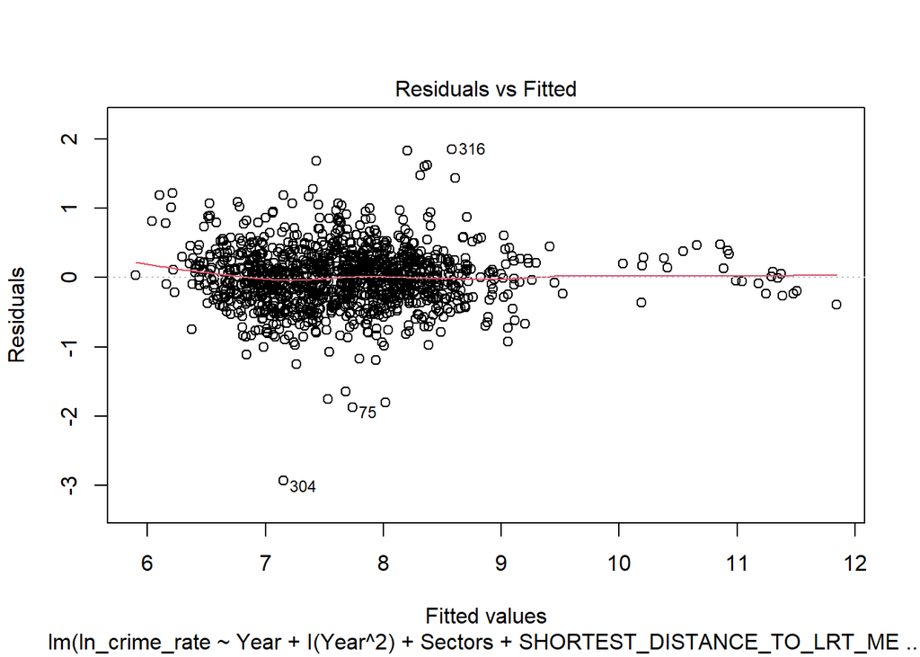

```r
plot(model6b, which=1)
```

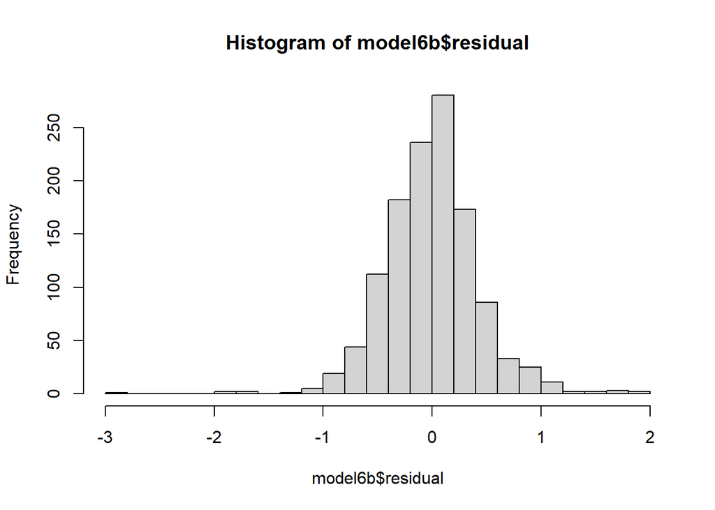

```r
hist(model6b$residual, breaks=25)
```

## Independence Assumption

2. Independence Assumption - Review residual against year (time), and residual against year spatial variable (sectors)

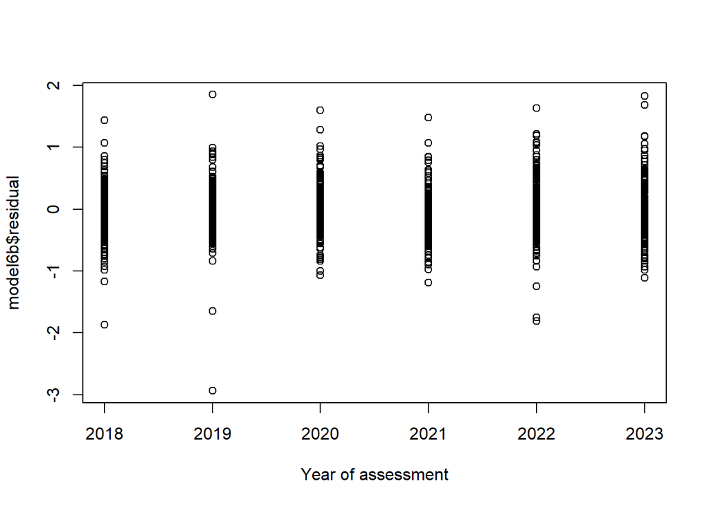

```r
plot(data_complete$Year, model6b$residual,
     xlab="Year of assessment") ## no discernible pattern over years?
```

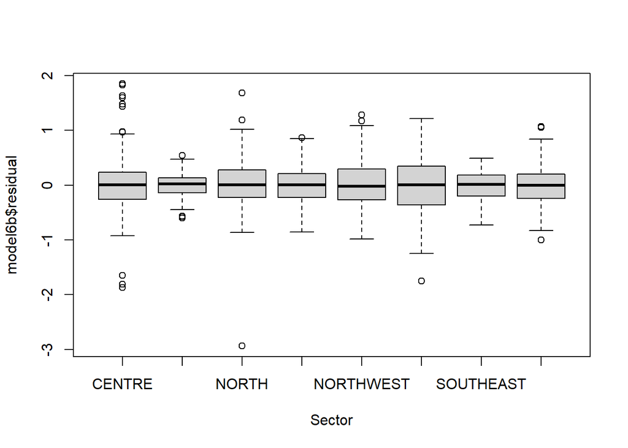

```r
boxplot(model6b$residual ~ data_complete$Sectors,
        xlab="Sector") ## no discernible pattern across sectors?
```

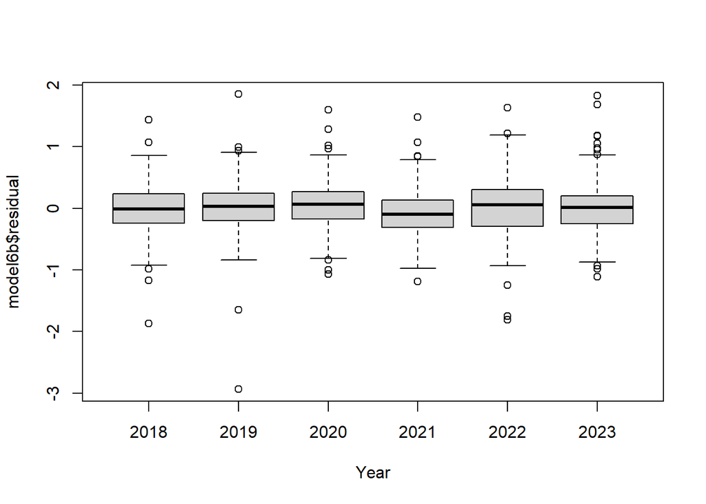

```r
boxplot(model6b$residual ~ data_complete$Year,
        xlab="Year")
```

## Normality Assumption

3. Normality Assumption - Using Shapiro-Wilk normality test; and normal qq plot, and histogram of residual

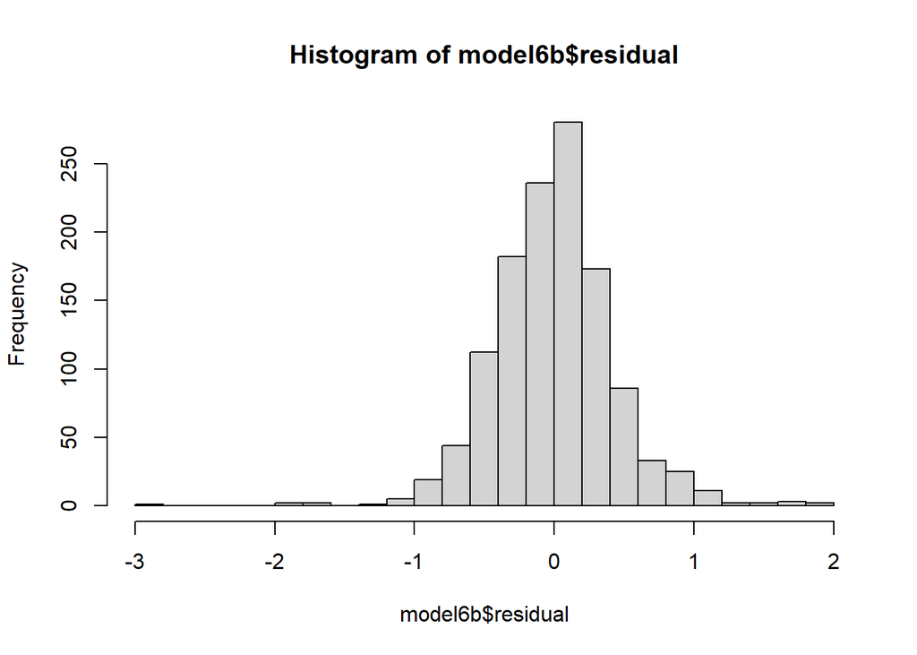

```r
hist(model6b$residual, breaks=25)
```

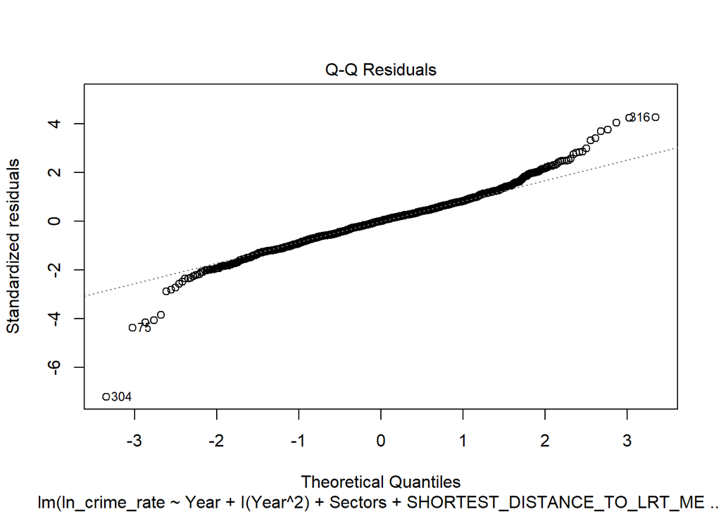

```r
plot(model6b, which=2) ## deviation at the tails
```

```r
shapiro.test(residuals(model6b))
```

```
##
##  Shapiro-Wilk normality test
##
## data:  residuals(model6b)
## W = 0.96829, p-value = 1.073e-15
```

```r
# we have a large sample, small deviation will likely result in rejecting the null
# hypothesis, but by the visual assessment of the QQ plot, it was not very
# far off, we consider our model is valid in terms of the normality assumption.
```

## Equal Variance Assumption

4. Equal Variance Assumption (heteroscedasticity) - Using Breusch-Pagan test residual vs. fitted value plots

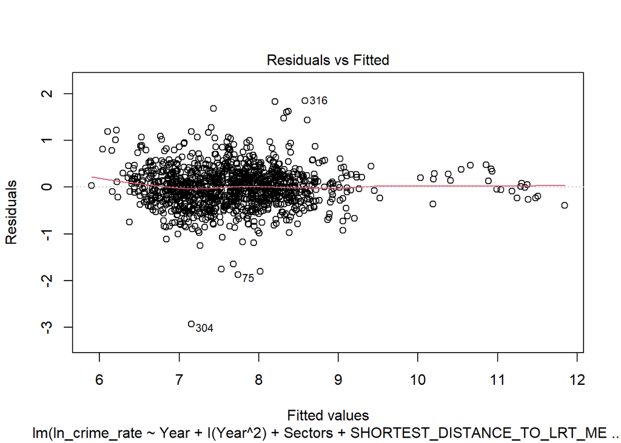

```r
plot(model6b, which=1)
```

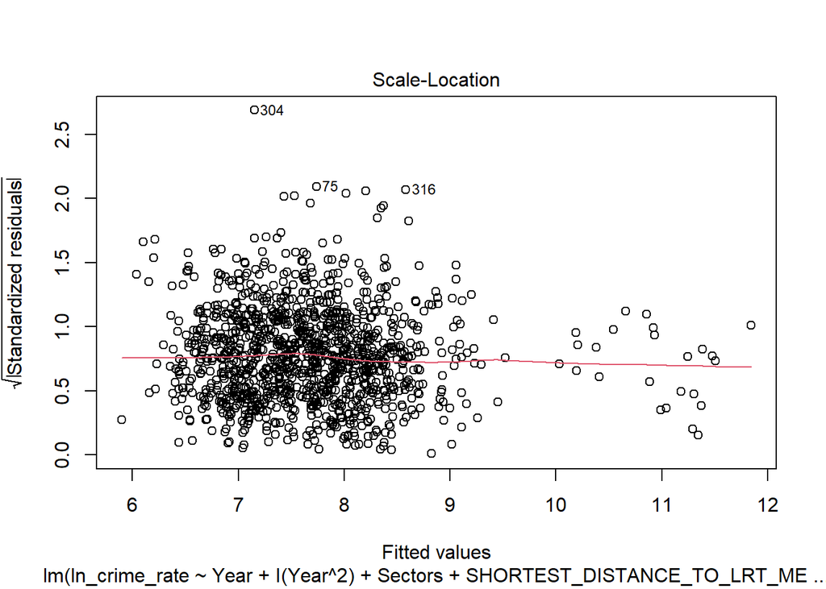

```r
plot(model6b, which=3) ## the scale location plot showed a bit of the variation of residuals decreases as fitted value increased; the line was quite horizontal straight.
```

```r
bptest(model6) ## p<0.05
```

```
##
##  studentized Breusch-Pagan test
##
## data:  model6
## BP = 185.71, df = 69, p-value = 1.21e-12
```

```r
# we have a large sample, small deviation will likely result in rejecting the null
# hypothesis, but by the visual assessment of the scale location plot,
# it was horizontal and was not very far off, but we can see that there were
# less data points that have the high fitted values, and that is probably where
# the BP test detected the deviation. But by the visual assessment of the scale
# location plot we did not see any megaphone shape signaling unequal variance,
# thus we consider our model is valid in terms of equal variance assumption.
```

## Multicollinearity - VIF

5. Multicollinearity - Using variance inflation factors (VIF)

When testing for multicollinearity, we don’t include interaction terms and squared terms, that means the model to be used for testing for multicollinearity would be model2, in which there were no variables with VIF>5.

First check if there were extremly high correltion between the predictors

```r
library(GGally)
```

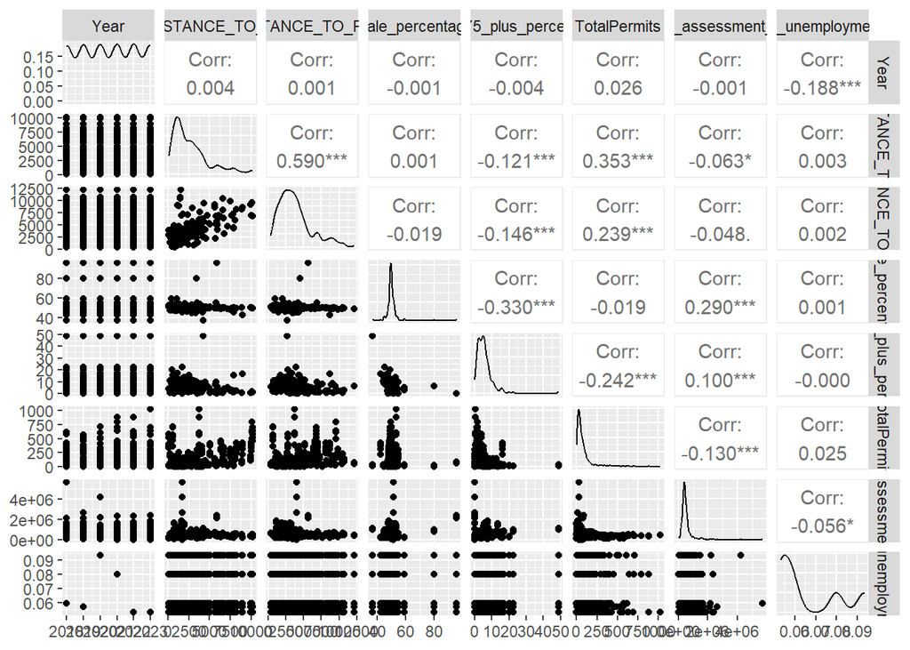

```r
ggpairs(data_complete[, c("Year",
"SHORTEST_DISTANCE_TO_LRT_METERS",
"SHORTEST_DISTANCE_TO_POLICE_METERS",
"male_percentage",
"age_75_plus_percentage",
"TotalPermits",
"property_assessment_median",
"canada_unemployment_rate")])
```

```r
# imcdiag(model6b, method="VIF")
imcdiag(model2, method="VIF")
```

```
##
## Call:
## imcdiag(mod = model2, method = "VIF")
##
##
##  VIF Multicollinearity Diagnostics
##
##                                       VIF detection
## Year                               1.0380         0
## SectorsEAST                        1.5052         0
## SectorsNORTH                       2.7094         0
## SectorsNORTHEAST                   1.3903         0
## SectorsNORTHWEST                   1.7401         0
## SectorsSOUTH                       1.5008         0
## SectorsSOUTHEAST                   2.1638         0
## SectorsWEST                        1.3881         0
## SHORTEST_DISTANCE_TO_LRT_METERS    4.1930         0
## SHORTEST_DISTANCE_TO_POLICE_METERS 2.3934         0
## male_percentage                    1.7299         0
## age_75_plus_percentage             1.3275         0
## TotalPermits                       1.2974         0
## property_assessment_median         1.2541         0
## canada_unemployment_rate           1.0418         0
##
## NOTE:  VIF Method Failed to detect multicollinearity
##
##
## 0 --> COLLINEARITY is not detected by the test
##
## ===================================
```

## Outliers - Cook’s Distance

6. Outliers - check Cook’s distance and leverage

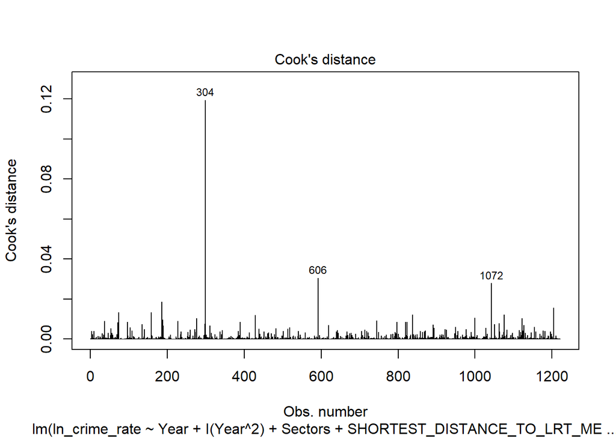

```r
plot (model6b, which=4) ## there was no outliers identified by Cook's distance >0.5, we can test with removing data point #304 later
```

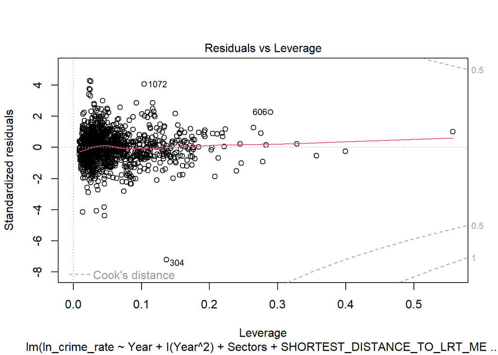

```r
plot (model6b, which=5)
```

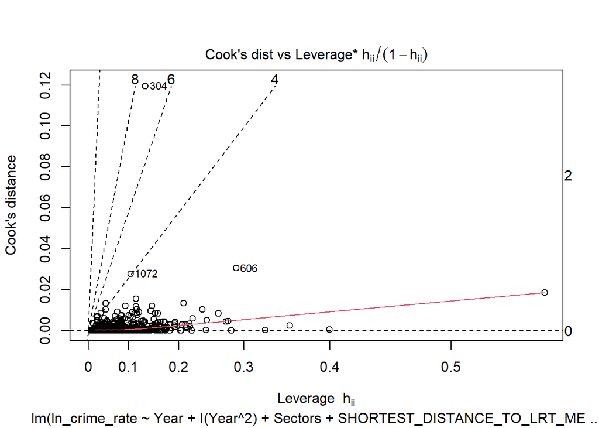

```r
plot (model6b, which=6)
```

```r
## leverage points

lev=hatvalues(model6b)
p = length(coef(model6b)) # 69
n = nrow(data_complete) # 1221
outlier2p = lev[lev>(2*p/n)]
outlier3p = lev[lev>(3*p/n)]
print("h_I>3p/n, outliers are")
```

```
## [1] "h_I>3p/n, outliers are"
```

```r
outlier3p
```

```
##        53        70        72        80       104       160       163       190
## 0.2191578 0.3570358 0.2643730 0.1840366 0.2233410 0.2081104 0.1739915 0.5571659
##       276       278       286       367       370       485       487       488
## 0.2463071 0.1923350 0.1720372 0.1762308 0.1737815 0.1748299 0.1763740 0.2217770
##       571       576       606       662       695       697       730       782
## 0.2182350 0.1758453 0.2896059 0.2048657 0.2111316 0.2126948 0.2781756 0.2026133
##       787       873       906       908       916       981       998      1084
## 0.1736040 0.1918221 0.2448878 0.2037992 0.1721569 0.1742843 0.1781484 0.3281803
##      1117      1119      1127      1145      1152      1204      1209      1212
## 0.3992907 0.2831334 0.1841097 0.2751178 0.2396372 0.1786719 0.1931886 0.1758830
##      1222
## 0.1932307
```

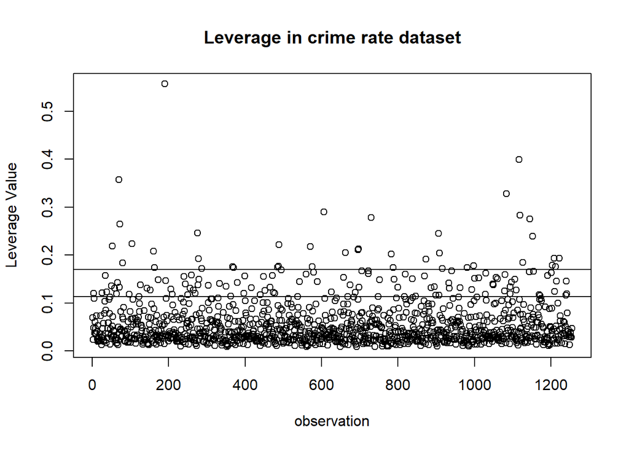

```r
# outlier2p = 2*69/1221 = 0.1130221
# outlier3p = 3*69/1221 = 0.1695332

plot(rownames(data_complete),lev, main = "Leverage in crime rate dataset", xlab="observation",
    ylab = "Leverage Value")
abline(h = 2 *p/n, lty = 1)
abline(h = 3 *p/n, lty = 1)
```

## Fit Model 7 - Removal of Outliers

Try to remove outlier3p/n and 2p/n and re-run model

```r
data_complete$lev <- hatvalues(model6b)

data_complete_out3p <- data_complete[data_complete$lev<=0.1695332,]
data_complete_out2p <- data_complete[data_complete$lev<=0.1130221,]
```

### Fit Model 7a - Removal of leverage >3p/n

```r
model7a <- lm(ln_crime_rate ~
Year+
I(Year^2)+
Sectors+
SHORTEST_DISTANCE_TO_LRT_METERS+
I(SHORTEST_DISTANCE_TO_LRT_METERS^2)+
I(SHORTEST_DISTANCE_TO_LRT_METERS^3)+
SHORTEST_DISTANCE_TO_POLICE_METERS+
male_percentage+
age_75_plus_percentage+
TotalPermits+
property_assessment_median+
canada_unemployment_rate+
Year*male_percentage+
Year*TotalPermits+
Sectors*SHORTEST_DISTANCE_TO_LRT_METERS+
Sectors*SHORTEST_DISTANCE_TO_POLICE_METERS+
Sectors*male_percentage+
Sectors*age_75_plus_percentage+
Sectors*TotalPermits+
Sectors*property_assessment_median+
SHORTEST_DISTANCE_TO_LRT_METERS*male_percentage+
SHORTEST_DISTANCE_TO_LRT_METERS*age_75_plus_percentage+
SHORTEST_DISTANCE_TO_LRT_METERS*TotalPermits+
SHORTEST_DISTANCE_TO_POLICE_METERS*property_assessment_median+
male_percentage*age_75_plus_percentage+
male_percentage*property_assessment_median, data_complete_out3p)

summary(model7a)
```

```
##
## Call:
## lm(formula = ln_crime_rate ~ Year + I(Year^2) + Sectors + SHORTEST_DISTANCE_TO_LRT_METERS +
##     I(SHORTEST_DISTANCE_TO_LRT_METERS^2) + I(SHORTEST_DISTANCE_TO_LRT_METERS^3) +
##     SHORTEST_DISTANCE_TO_POLICE_METERS + male_percentage + age_75_plus_percentage +
##     TotalPermits + property_assessment_median + canada_unemployment_rate +
##     Year * male_percentage + Year * TotalPermits + Sectors *
##     SHORTEST_DISTANCE_TO_LRT_METERS + Sectors * SHORTEST_DISTANCE_TO_POLICE_METERS +
##     Sectors * male_percentage + Sectors * age_75_plus_percentage +
##     Sectors * TotalPermits + Sectors * property_assessment_median +
##     SHORTEST_DISTANCE_TO_LRT_METERS * male_percentage + SHORTEST_DISTANCE_TO_LRT_METERS *
##     age_75_plus_percentage + SHORTEST_DISTANCE_TO_LRT_METERS *
##     TotalPermits + SHORTEST_DISTANCE_TO_POLICE_METERS * property_assessment_median +
##     male_percentage * age_75_plus_percentage + male_percentage *
##     property_assessment_median, data = data_complete_out3p)
##
## Residuals:
##      Min       1Q   Median       3Q      Max
## -2.92000 -0.25221  0.00218  0.23562  1.83171
##
## Coefficients:
##                                                                 Estimate
## (Intercept)                                                   -8.649e+04
## Year                                                           8.604e+01
## I(Year^2)                                                     -2.140e-02
## SectorsEAST                                                   -6.967e+00
## SectorsNORTH                                                   2.048e+01
## SectorsNORTHEAST                                               9.449e+00
## SectorsNORTHWEST                                              -6.805e-01
## SectorsSOUTH                                                  -1.864e+00
## SectorsSOUTHEAST                                               5.637e+00
## SectorsWEST                                                    1.063e+00
## SHORTEST_DISTANCE_TO_LRT_METERS                               -3.909e-03
## I(SHORTEST_DISTANCE_TO_LRT_METERS^2)                           8.530e-08
## I(SHORTEST_DISTANCE_TO_LRT_METERS^3)                          -4.325e-12
## SHORTEST_DISTANCE_TO_POLICE_METERS                             1.133e-05
## male_percentage                                               -1.245e+01
## age_75_plus_percentage                                         3.441e-01
## TotalPermits                                                  -9.183e-01
## property_assessment_median                                    -2.825e-07
```

[output cut: 252 more lines]

```
## SectorsSOUTH:property_assessment_median                       ***
## SectorsSOUTHEAST:property_assessment_median
## SectorsWEST:property_assessment_median
## SHORTEST_DISTANCE_TO_LRT_METERS:male_percentage               ***
## SHORTEST_DISTANCE_TO_LRT_METERS:age_75_plus_percentage        ***
## SHORTEST_DISTANCE_TO_LRT_METERS:TotalPermits                  *
## SHORTEST_DISTANCE_TO_POLICE_METERS:property_assessment_median **
## male_percentage:age_75_plus_percentage                        ***
## male_percentage:property_assessment_median
## ---
## Signif. codes:  0 '***' 0.001 '**' 0.01 '*' 0.05 '.' 0.1 ' ' 1
##
## Residual standard error: 0.4323 on 1111 degrees of freedom
## Multiple R-squared:  0.7117, Adjusted R-squared:  0.694
## F-statistic: 40.33 on 68 and 1111 DF,  p-value: < 2.2e-16
```

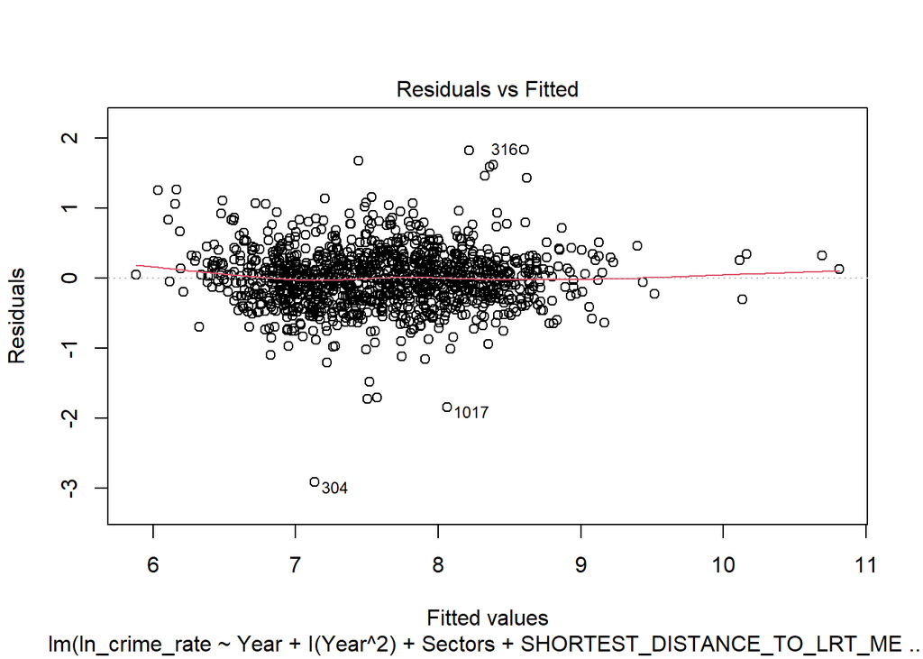

```r
plot(model7a, which=1)
```

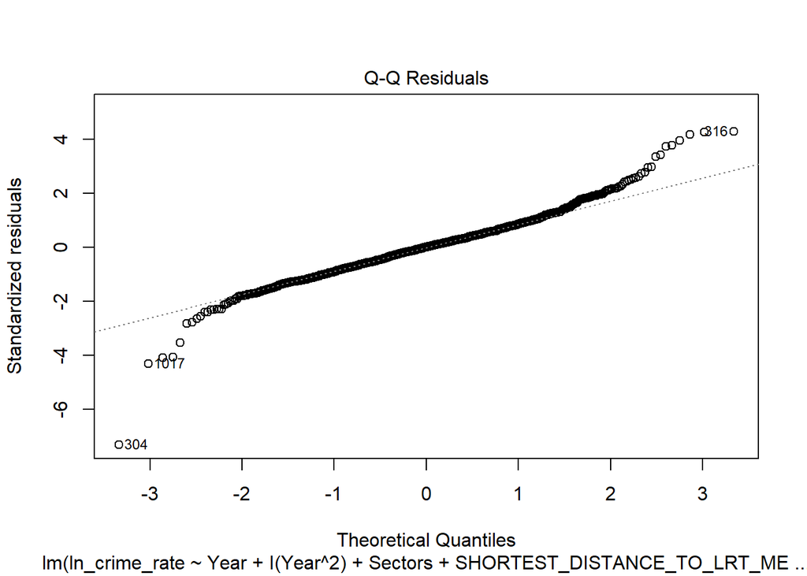

```r
plot(model7a, which=2)
```

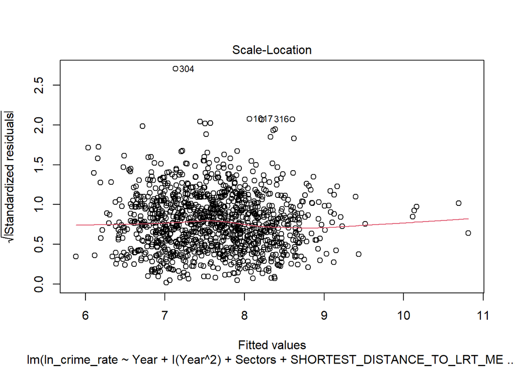

```r
plot(model7a, which=3) # improved
```

```r
shapiro.test(residuals(model7a)) ## still not pass
```

```
##
##  Shapiro-Wilk normality test
##
## data:  residuals(model7a)
## W = 0.96811, p-value = 1.951e-15
```

```r
bptest(model7a)  ## still not pass
```

```
##
##  studentized Breusch-Pagan test
##
## data:  model7a
## BP = 189.94, df = 68, p-value = 1.813e-13
```

### Fit Model 7b - Removal of leverage >2p/n

```r
model7b <- lm(ln_crime_rate ~
Year+
I(Year^2)+
Sectors+
SHORTEST_DISTANCE_TO_LRT_METERS+
I(SHORTEST_DISTANCE_TO_LRT_METERS^2)+
I(SHORTEST_DISTANCE_TO_LRT_METERS^3)+
SHORTEST_DISTANCE_TO_POLICE_METERS+
male_percentage+
age_75_plus_percentage+
TotalPermits+
property_assessment_median+
canada_unemployment_rate+
Year*male_percentage+
Year*TotalPermits+
Sectors*SHORTEST_DISTANCE_TO_LRT_METERS+
Sectors*SHORTEST_DISTANCE_TO_POLICE_METERS+
Sectors*male_percentage+
Sectors*age_75_plus_percentage+
Sectors*TotalPermits+
Sectors*property_assessment_median+
SHORTEST_DISTANCE_TO_LRT_METERS*male_percentage+
SHORTEST_DISTANCE_TO_LRT_METERS*age_75_plus_percentage+
SHORTEST_DISTANCE_TO_LRT_METERS*TotalPermits+
SHORTEST_DISTANCE_TO_POLICE_METERS*property_assessment_median+
male_percentage*age_75_plus_percentage+
male_percentage*property_assessment_median, data_complete_out2p)

summary(model7b)
```

```
##
## Call:
## lm(formula = ln_crime_rate ~ Year + I(Year^2) + Sectors + SHORTEST_DISTANCE_TO_LRT_METERS +
##     I(SHORTEST_DISTANCE_TO_LRT_METERS^2) + I(SHORTEST_DISTANCE_TO_LRT_METERS^3) +
##     SHORTEST_DISTANCE_TO_POLICE_METERS + male_percentage + age_75_plus_percentage +
##     TotalPermits + property_assessment_median + canada_unemployment_rate +
##     Year * male_percentage + Year * TotalPermits + Sectors *
##     SHORTEST_DISTANCE_TO_LRT_METERS + Sectors * SHORTEST_DISTANCE_TO_POLICE_METERS +
##     Sectors * male_percentage + Sectors * age_75_plus_percentage +
##     Sectors * TotalPermits + Sectors * property_assessment_median +
##     SHORTEST_DISTANCE_TO_LRT_METERS * male_percentage + SHORTEST_DISTANCE_TO_LRT_METERS *
##     age_75_plus_percentage + SHORTEST_DISTANCE_TO_LRT_METERS *
##     TotalPermits + SHORTEST_DISTANCE_TO_POLICE_METERS * property_assessment_median +
##     male_percentage * age_75_plus_percentage + male_percentage *
##     property_assessment_median, data = data_complete_out2p)
##
## Residuals:
##      Min       1Q   Median       3Q      Max
## -1.90111 -0.25208 -0.00448  0.22511  1.81637
##
## Coefficients:
##                                                                 Estimate
## (Intercept)                                                   -8.018e+04
## Year                                                           7.971e+01
## I(Year^2)                                                     -1.981e-02
## SectorsEAST                                                   -7.556e+00
## SectorsNORTH                                                   2.281e+01
## SectorsNORTHEAST                                               8.485e+00
## SectorsNORTHWEST                                               5.252e+00
## SectorsSOUTH                                                   6.336e-01
## SectorsSOUTHEAST                                               1.204e+01
## SectorsWEST                                                    2.619e+00
## SHORTEST_DISTANCE_TO_LRT_METERS                               -3.611e-03
## I(SHORTEST_DISTANCE_TO_LRT_METERS^2)                           8.180e-08
## I(SHORTEST_DISTANCE_TO_LRT_METERS^3)                          -3.853e-12
## SHORTEST_DISTANCE_TO_POLICE_METERS                            -3.208e-05
## male_percentage                                               -9.154e+00
## age_75_plus_percentage                                        -3.028e-01
## TotalPermits                                                  -8.398e-01
## property_assessment_median                                     5.590e-06
```

[output cut: 252 more lines]

```
## SectorsSOUTH:property_assessment_median                       **
## SectorsSOUTHEAST:property_assessment_median
## SectorsWEST:property_assessment_median
## SHORTEST_DISTANCE_TO_LRT_METERS:male_percentage               ***
## SHORTEST_DISTANCE_TO_LRT_METERS:age_75_plus_percentage        **
## SHORTEST_DISTANCE_TO_LRT_METERS:TotalPermits                  *
## SHORTEST_DISTANCE_TO_POLICE_METERS:property_assessment_median
## male_percentage:age_75_plus_percentage                        *
## male_percentage:property_assessment_median                    ***
## ---
## Signif. codes:  0 '***' 0.001 '**' 0.01 '*' 0.05 '.' 0.1 ' ' 1
##
## Residual standard error: 0.4154 on 1010 degrees of freedom
## Multiple R-squared:  0.7063, Adjusted R-squared:  0.6865
## F-statistic: 35.72 on 68 and 1010 DF,  p-value: < 2.2e-16
```

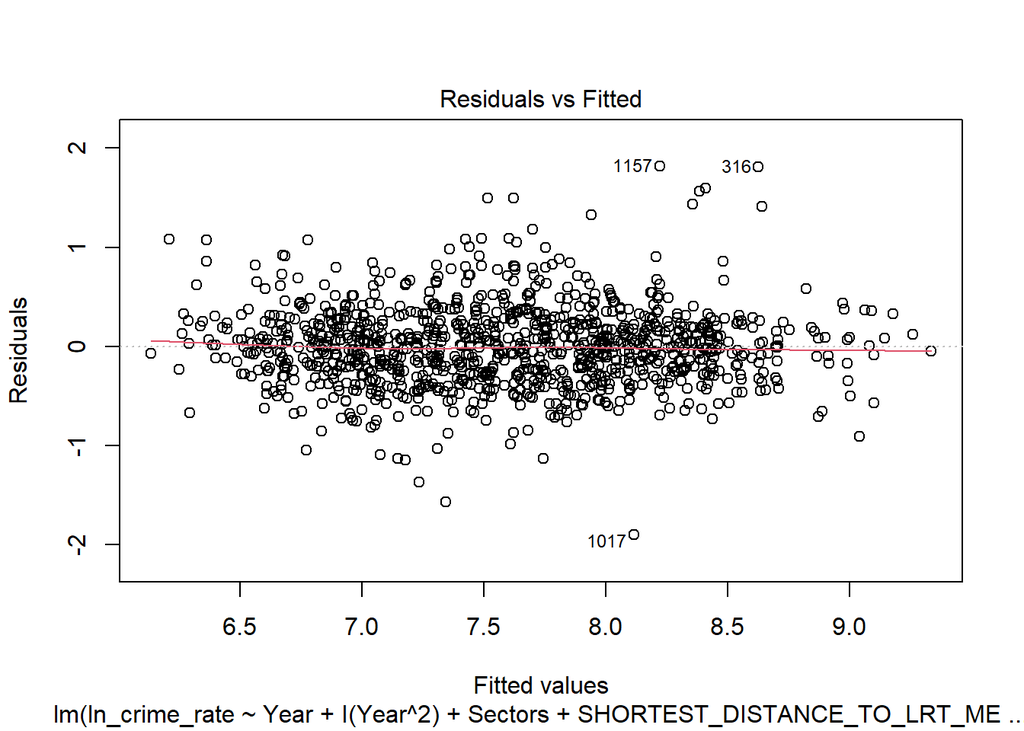

```r
plot(model7b, which=1)
```

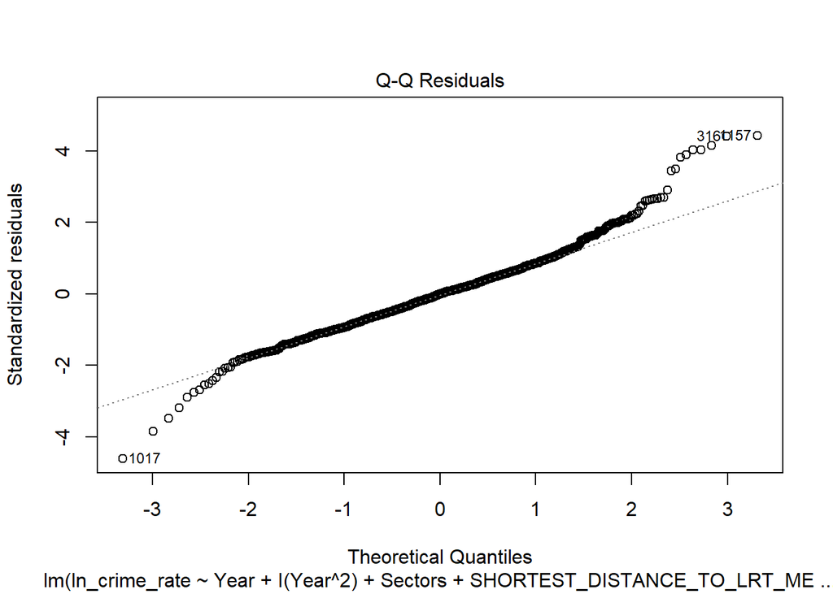

```r
plot(model7b, which=2)
```

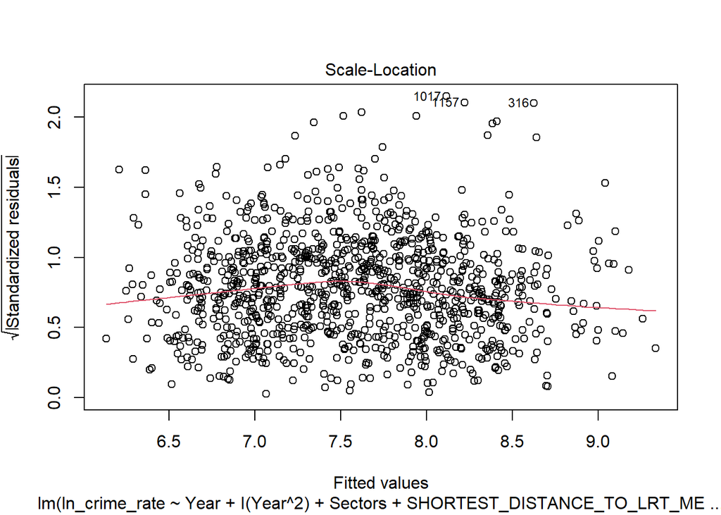

```r
plot(model7b, which=3) # improved
```

```r
shapiro.test(residuals(model7b)) ## still not pass
```

```
##
##  Shapiro-Wilk normality test
##
## data:  residuals(model7b)
## W = 0.97625, p-value = 2.686e-12
```

```r
bptest(model7b)  ## still not pass
```

```
##
##  studentized Breusch-Pagan test
##
## data:  model7b
## BP = 177.41, df = 68, p-value = 1.04e-11
```

### Fit Model 7c - Removal of data point #304

```r
# review : data point #304
```

```r
data_complete_rm304 <- data_complete[data_complete$Total_Crime_Count>1,]
```

```r
model7c <- lm(ln_crime_rate ~
Year+
I(Year^2)+
Sectors+
SHORTEST_DISTANCE_TO_LRT_METERS+
I(SHORTEST_DISTANCE_TO_LRT_METERS^2)+
I(SHORTEST_DISTANCE_TO_LRT_METERS^3)+
SHORTEST_DISTANCE_TO_POLICE_METERS+
male_percentage+
age_75_plus_percentage+
TotalPermits+
property_assessment_median+
canada_unemployment_rate+
Year*male_percentage+
Year*TotalPermits+
Sectors*SHORTEST_DISTANCE_TO_LRT_METERS+
Sectors*SHORTEST_DISTANCE_TO_POLICE_METERS+
Sectors*male_percentage+
Sectors*age_75_plus_percentage+
Sectors*TotalPermits+
Sectors*property_assessment_median+
SHORTEST_DISTANCE_TO_LRT_METERS*male_percentage+
SHORTEST_DISTANCE_TO_LRT_METERS*age_75_plus_percentage+
SHORTEST_DISTANCE_TO_LRT_METERS*TotalPermits+
SHORTEST_DISTANCE_TO_POLICE_METERS*property_assessment_median+
male_percentage*age_75_plus_percentage+
male_percentage*property_assessment_median, data_complete_rm304)


summary(model7c)
```

```
##
## Call:
## lm(formula = ln_crime_rate ~ Year + I(Year^2) + Sectors + SHORTEST_DISTANCE_TO_LRT_METERS +
##     I(SHORTEST_DISTANCE_TO_LRT_METERS^2) + I(SHORTEST_DISTANCE_TO_LRT_METERS^3) +
##     SHORTEST_DISTANCE_TO_POLICE_METERS + male_percentage + age_75_plus_percentage +
##     TotalPermits + property_assessment_median + canada_unemployment_rate +
##     Year * male_percentage + Year * TotalPermits + Sectors *
##     SHORTEST_DISTANCE_TO_LRT_METERS + Sectors * SHORTEST_DISTANCE_TO_POLICE_METERS +
##     Sectors * male_percentage + Sectors * age_75_plus_percentage +
##     Sectors * TotalPermits + Sectors * property_assessment_median +
##     SHORTEST_DISTANCE_TO_LRT_METERS * male_percentage + SHORTEST_DISTANCE_TO_LRT_METERS *
##     age_75_plus_percentage + SHORTEST_DISTANCE_TO_LRT_METERS *
##     TotalPermits + SHORTEST_DISTANCE_TO_POLICE_METERS * property_assessment_median +
##     male_percentage * age_75_plus_percentage + male_percentage *
##     property_assessment_median, data = data_complete_rm304)
##
## Residuals:
##      Min       1Q   Median       3Q      Max
## -1.87335 -0.24979  0.00502  0.23170  1.85058
##
## Coefficients:
##                                                                 Estimate
## (Intercept)                                                   -8.197e+04
## Year                                                           8.146e+01
## I(Year^2)                                                     -2.024e-02
## SectorsEAST                                                   -1.442e+00
## SectorsNORTH                                                   1.421e+01
## SectorsNORTHEAST                                               6.849e+00
## SectorsNORTHWEST                                              -7.439e+00
## SectorsSOUTH                                                  -4.939e+00
## SectorsSOUTHEAST                                              -4.602e+00
## SectorsWEST                                                   -1.946e+00
## SHORTEST_DISTANCE_TO_LRT_METERS                               -2.357e-03
## I(SHORTEST_DISTANCE_TO_LRT_METERS^2)                           6.368e-08
## I(SHORTEST_DISTANCE_TO_LRT_METERS^3)                          -3.451e-12
## SHORTEST_DISTANCE_TO_POLICE_METERS                             6.803e-06
## male_percentage                                               -8.583e+00
## age_75_plus_percentage                                         2.464e-01
## TotalPermits                                                  -7.914e-01
## property_assessment_median                                     4.196e-06
```

[output cut: 252 more lines]

```
## SectorsSOUTH:property_assessment_median                       ***
## SectorsSOUTHEAST:property_assessment_median                   *
## SectorsWEST:property_assessment_median
## SHORTEST_DISTANCE_TO_LRT_METERS:male_percentage               ***
## SHORTEST_DISTANCE_TO_LRT_METERS:age_75_plus_percentage        ***
## SHORTEST_DISTANCE_TO_LRT_METERS:TotalPermits                  ***
## SHORTEST_DISTANCE_TO_POLICE_METERS:property_assessment_median **
## male_percentage:age_75_plus_percentage                        ***
## male_percentage:property_assessment_median                    ***
## ---
## Signif. codes:  0 '***' 0.001 '**' 0.01 '*' 0.05 '.' 0.1 ' ' 1
##
## Residual standard error: 0.4277 on 1151 degrees of freedom
## Multiple R-squared:  0.7809, Adjusted R-squared:  0.768
## F-statistic: 60.34 on 68 and 1151 DF,  p-value: < 2.2e-16
```

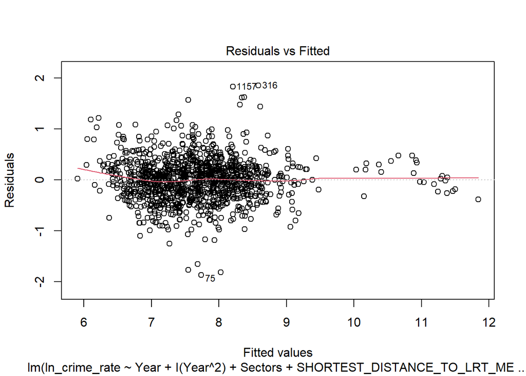

```r
plot(model7c, which=1)
```

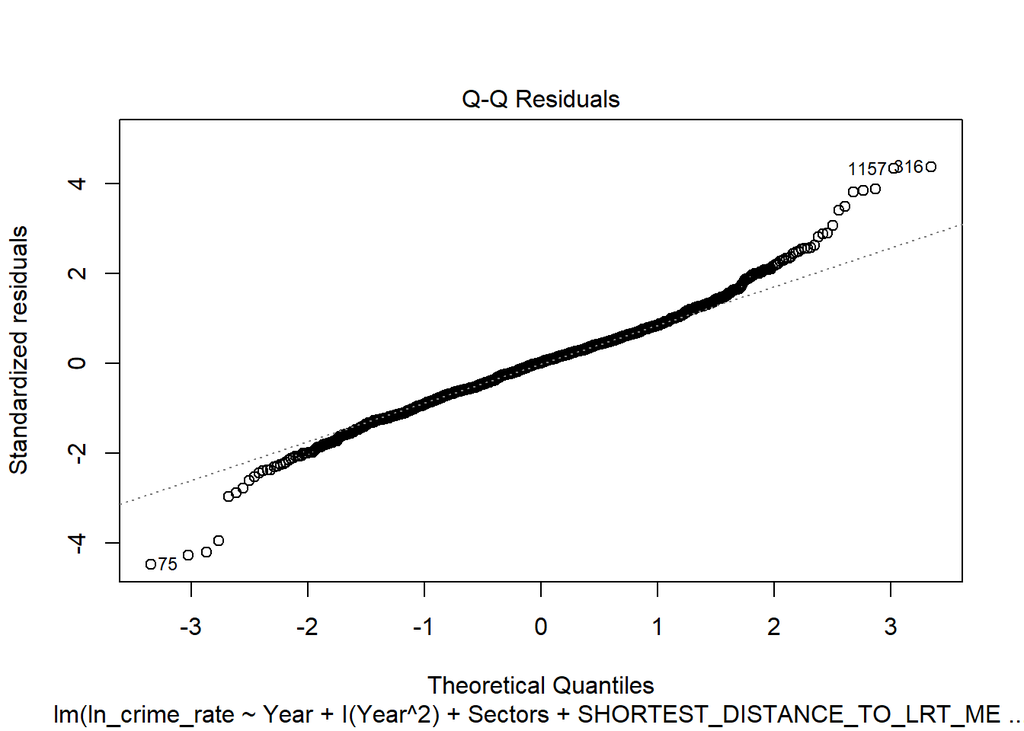

```r
plot(model7c, which=2)
```

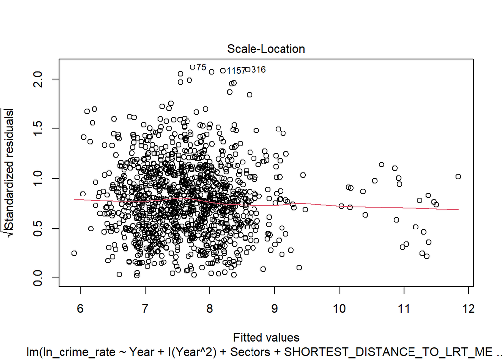

```r
plot(model7c, which=3)
```

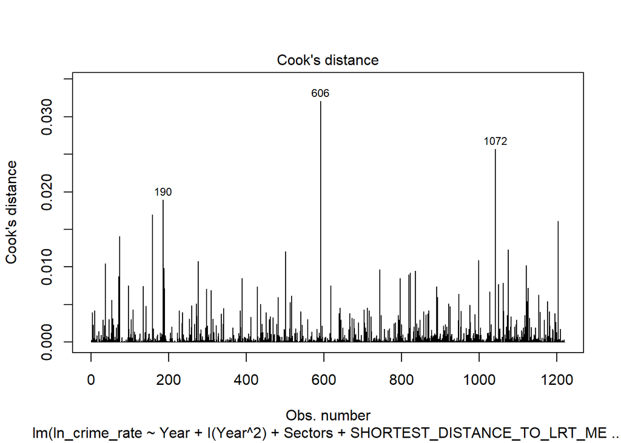

```r
plot(model7c, which=4)
```

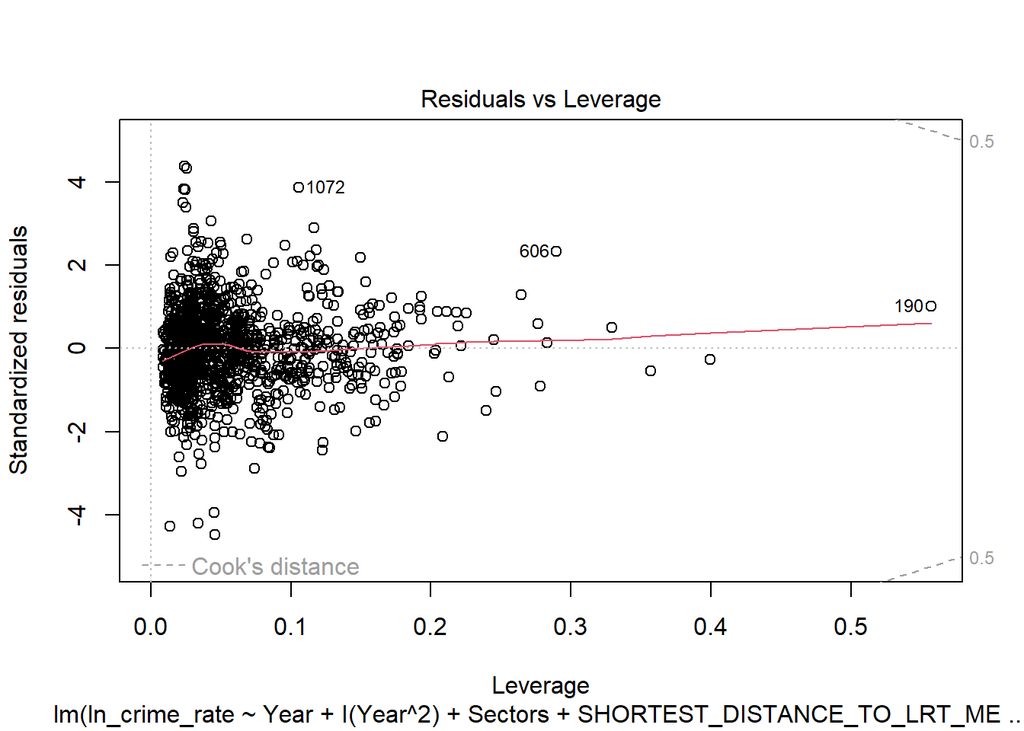

```r
plot(model7c, which=5)
```

```r
shapiro.test(residuals(model7c))
```

```
##
##  Shapiro-Wilk normality test
##
## data:  residuals(model7c)
## W = 0.97984, p-value = 5.223e-12
```

```r
bptest(model7c)
```

```
##
##  studentized Breusch-Pagan test
##
## data:  model7c
## BP = 140.23, df = 68, p-value = 6.16e-07
```

# Prediction Plot

Use our best model, focus on Calgary Communities that will be impacted by the future Green LRT Line.

Use the proposed Green Leg LRT Transit Station locations to update one of our predictor variables dataset to a new shortest LRT distance in meters.

```r
final_model<-model6b
# New distances - in report - Appendix A explain where this set comes from - these distances reflect Green Line LRT locations so these communities now have a closer LRT location than what currently exists
new_distances <- c(
  SHI = 614.656, BLN = 252.401, MCT = 350.192, OGD = 882.95,
  CRE = 80.9746, SET = 484.164, ESH = 2005.62, THO = 465.315,
  HAR = 1159.98, TUX = 517.127, AUB = 1097.43, HIF = 377.187,
  AYB = 474.015, HPK = 29.6261, BED = 1047, HUN = 566.373,
  LIV = 671.398, CAR = 756.349, CHV = 638.325, RAM = 584.051,
  DNC = 76.8825, EAU = 373.508
)
# Initialize a list to store data frames for each community code
community_data <- list()
```

## Current LRT Status Prediction

We will use our Regression Model and predict the Crime Rate based on our current dataset, for presentation and visualization, I will revert the Log of Crime Rate back to Crime Count.